# Software Faultiness Analysis - Marco Gatto

### Data transformation - Outliers Removal - Threshold = 1

In order to remove the outliers according to a threshold value equal to 1, the same function defined before is used.

```r
nonOutliersCook1 <- removeOutliersCook1(moa, sw_fault)
```

In order to make the code more clear, two new variables are created.

```r
nonOutliersCook1_moa <- nonOutliersCook1[[1]]
nonOutliersCook1_sw_fault <- nonOutliersCook1[[2]]
```

Before the correlation coefficient are computed on the new data, it is important to check how many data-points has been removed.

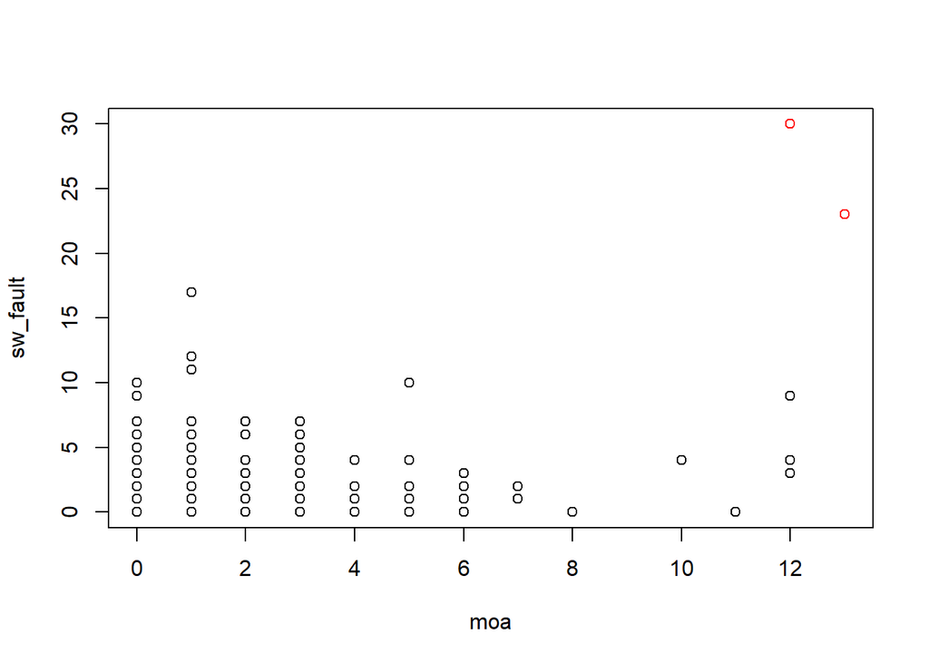

```r
plot(moa, sw_fault, col="red")
points(nonOutliersCook1_moa, nonOutliersCook1_sw_fault, col="black")
```

The model is finally re-created and the OLS assumptions are checked on the data with the outliers removed.

```r
nonOutliersCook1_sw_faultsVSmoa <- lm(nonOutliersCook1_sw_fault~nonOutliersCook1_moa)

nonOutliersCook1_corrCoeff <- correlation.coefficients(nonOutliersCook1_moa,
                                                        nonOutliersCook1_sw_fault,
                                                        nonOutliersCook1_sw_faultsVSmoa)
```

```
##
##  Pearson's product-moment correlation
##
## data:  x and y
## t = 1.8222, df = 336, p-value = 0.03466
## alternative hypothesis: true correlation is greater than 0
## 95 percent confidence interval:
##  0.009375676 1.000000000
## sample estimates:
##        cor
## 0.09891935
##
##
##  Spearman's rank correlation rho
##
## data:  y and x
## S = 5702251, p-value = 0.03624
## alternative hypothesis: true rho is not equal to 0
## sample estimates:
##       rho
## 0.1139642
##
##
##  Kendall's rank correlation tau
##
## data:  y and x
## z = 2.0793, p-value = 0.0188
## alternative hypothesis: true tau is greater than 0
## sample estimates:
##        tau
## 0.09387212
##
##
##  Shapiro-Wilk normality test
##
## data:  ols_model$residuals
## W = 0.77562, p-value < 2.2e-16
```

```r
colnames(nonOutliersCook1_corrCoeff) <- c('NonOutCook1_SwFaultVSMOA')
nonOutliersCook1_corrCoeff
```

```
##                      NonOutCook1_SwFaultVSMOA
## Pearson's R                      9.891935e-02
## Spearman's Rho                   1.139642e-01
## Kendall's Tau                    9.387212e-02
## Shapiro-Wilk p-value             3.317458e-21
```

According to the obtained results and with the results obtained on the original data, all the results are worse. Furthermore, the p-value computed by the Shapiro-Wilk test is still less than 0.05. So, this transformation did not work in this situation.

It is also possible to graphically check the differences between the two OLS lines of regression.

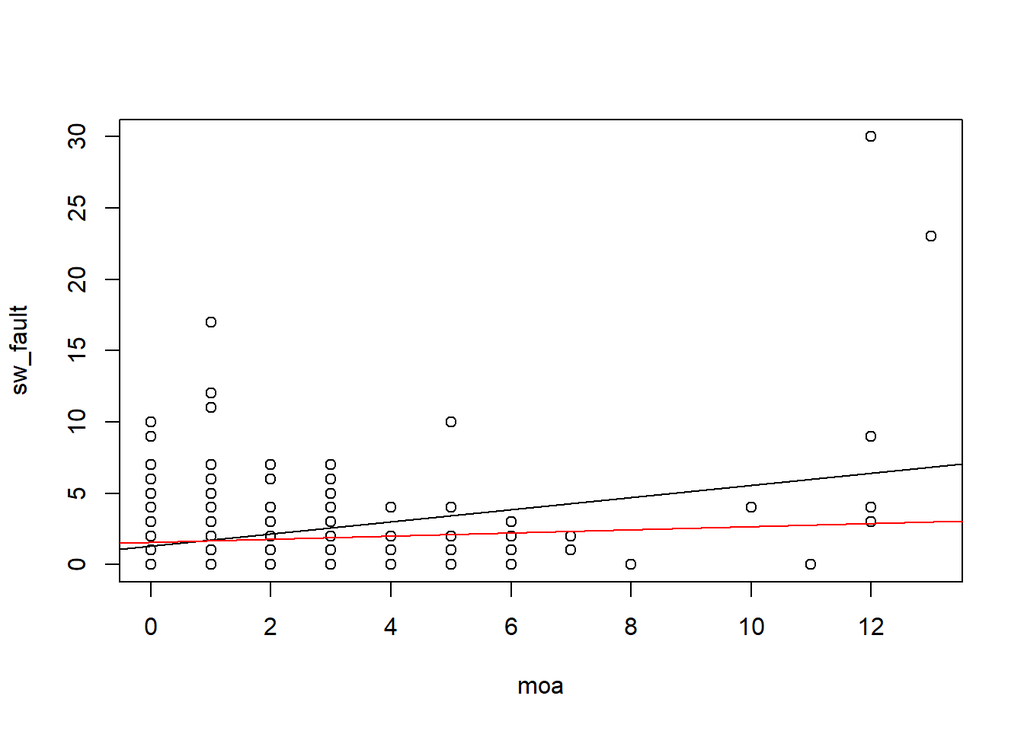

```r
plot(moa, sw_fault)
abline(sw_faultVSmoa)
abline(nonOutliersCook1_sw_faultsVSmoa, col="red")
```

### Data transformation - Outliers Removal - Threshold = 4/L

In order to remove the outliers according to a threshold value equal to 4/L, the same function defined before is used.

```r
nonOutliersCook4l <- removeOutliersCook4l(moa, sw_fault)
```

In order to make the code more clear, two new variables are created.

```r
nonOutliersCook4l_moa <- nonOutliersCook4l[[1]]
nonOutliersCook4l_sw_fault <- nonOutliersCook4l[[2]]
```

Before the correlation coefficient are computed on the new data, it is important to check how many data-points has been removed.

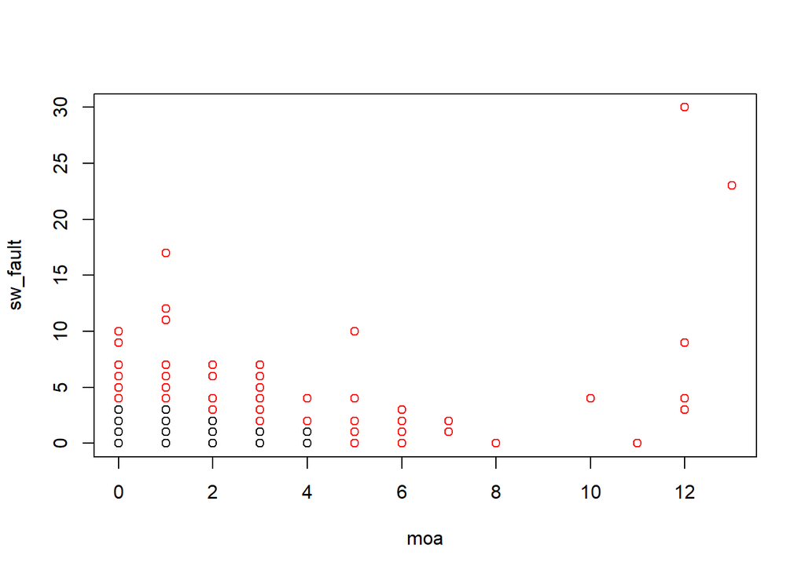

```r
plot(moa, sw_fault, col="red")
points(nonOutliersCook4l_moa, nonOutliersCook4l_sw_fault, col="black")
```

Even in this case, the scatterplot shows that a very huge number of data-points has been considered outliers and has been removed from the original data. This is a possible reason to support the choice to consider this model as not statistically-significant.

```r
cat("Data-points in the original data:",
    length(sw_fault))
```

```
## Data-points in the original data: 340
```

```r
cat("Data-points removed from the original data:",
    length(sw_fault) - length(nonOutliersCook4l_sw_fault))
```

```
## Data-points removed from the original data: 93
```

The model is finally re-created and the OLS assumptions are checked on the data with the outliers removed.

```r
nonOutliersCook4l_sw_faultsVSmoa <- lm(nonOutliersCook4l_sw_fault~nonOutliersCook4l_moa)

nonOutliersCook4l_corrCoeff <- correlation.coefficients(nonOutliersCook4l_moa,
                                                        nonOutliersCook4l_sw_fault,
                                                        nonOutliersCook4l_sw_faultsVSmoa)
```

```
##
##  Pearson's product-moment correlation
##
## data:  x and y
## t = -1.4972, df = 245, p-value = 0.9322
## alternative hypothesis: true correlation is greater than 0
## 95 percent confidence interval:
##  -0.1981512  1.0000000
## sample estimates:
##         cor
## -0.09521714
##
##
##  Spearman's rank correlation rho
##
## data:  y and x
## S = 2620328, p-value = 0.4978
## alternative hypothesis: true rho is not equal to 0
## sample estimates:
##         rho
## -0.04333342
##
##
##  Kendall's rank correlation tau
##
## data:  y and x
## z = -0.69154, p-value = 0.7554
## alternative hypothesis: true tau is greater than 0
## sample estimates:
##         tau
## -0.03933399
##
##
##  Shapiro-Wilk normality test
##
## data:  ols_model$residuals
## W = 0.81169, p-value < 2.2e-16
```

```r
colnames(nonOutliersCook4l_corrCoeff) <- c('NonOutCook4l_SwFaultVSMOA')
nonOutliersCook4l_corrCoeff
```

```
##                      NonOutCook4l_SwFaultVSMOA
## Pearson's R                      -9.521714e-02
## Spearman's Rho                   -4.333342e-02
## Kendall's Tau                    -3.933399e-02
## Shapiro-Wilk p-value              1.357935e-16
```

Comparing the obtained results with the ones obtained on the original data, all the results show worse results. In particular, all the values of the correlation coefficients have changed from low values quite near to 0 to negative values quite near to 0. The p-value computed by the Shapiro-Wilk test is still less than 0.05. So, this transformation did not work in this situation.

It is also possible to graphically check the differences between the two OLS lines of regression.

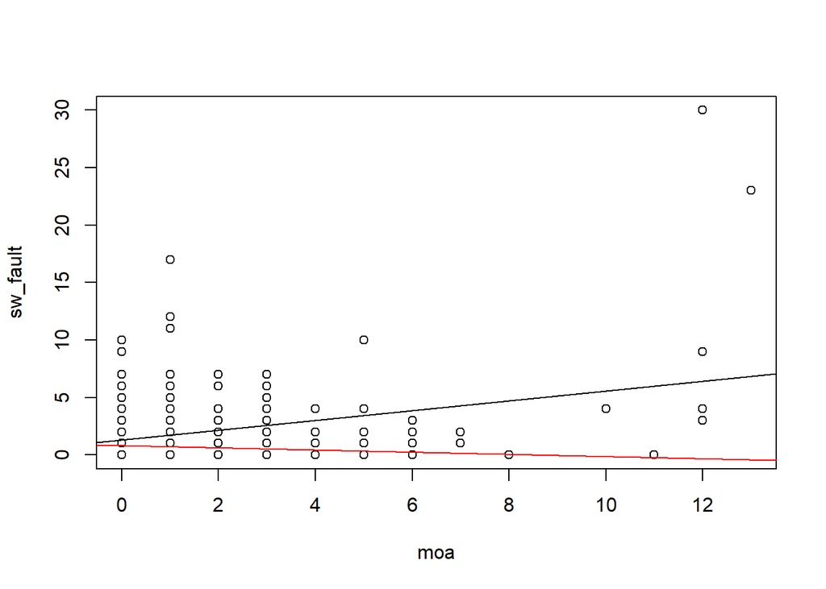

```r
plot(moa, sw_fault)
abline(sw_faultVSmoa)
abline(nonOutliersCook4l_sw_faultsVSmoa, col="red")
```

### Final considerations

The application of the OLS technique on the variables MOA and Software Faultiness is not possible, because these two variables are not linearly dependent.

In particular, it is possible to report the main coefficient that evaluate the linear dependency of these two variables over the different analysis performed.

```r
cbind(orig_corrCoeff, log_corrCoeff, nonOutliersCook1_corrCoeff, nonOutliersCook4l_corrCoeff)
```

```
##                      SwFaultVSMOA Log_SwFaultVSMOA NonOutCook1_SwFaultVSMOA
## Pearson's R          3.169566e-01     1.704285e-01             9.891935e-02
## Spearman's Rho       1.314528e-01     1.314528e-01             1.139642e-01
## Kendall's Tau        1.085797e-01     1.085797e-01             9.387212e-02
## Shapiro-Wilk p-value 1.224719e-22     3.891942e-12             3.317458e-21
##                      NonOutCook4l_SwFaultVSMOA
## Pearson's R                      -9.521714e-02
## Spearman's Rho                   -4.333342e-02
## Kendall's Tau                    -3.933399e-02
## Shapiro-Wilk p-value              1.357935e-16
```

Looking at the above table, it is possible to state that only the original data show a very slight degree of correlation. In particular, all the data transformation techniques reduce the degree of linear dependency among the two variables.

## Univariate statistically-significant model - OLS - Software Faultiness vs LCOM

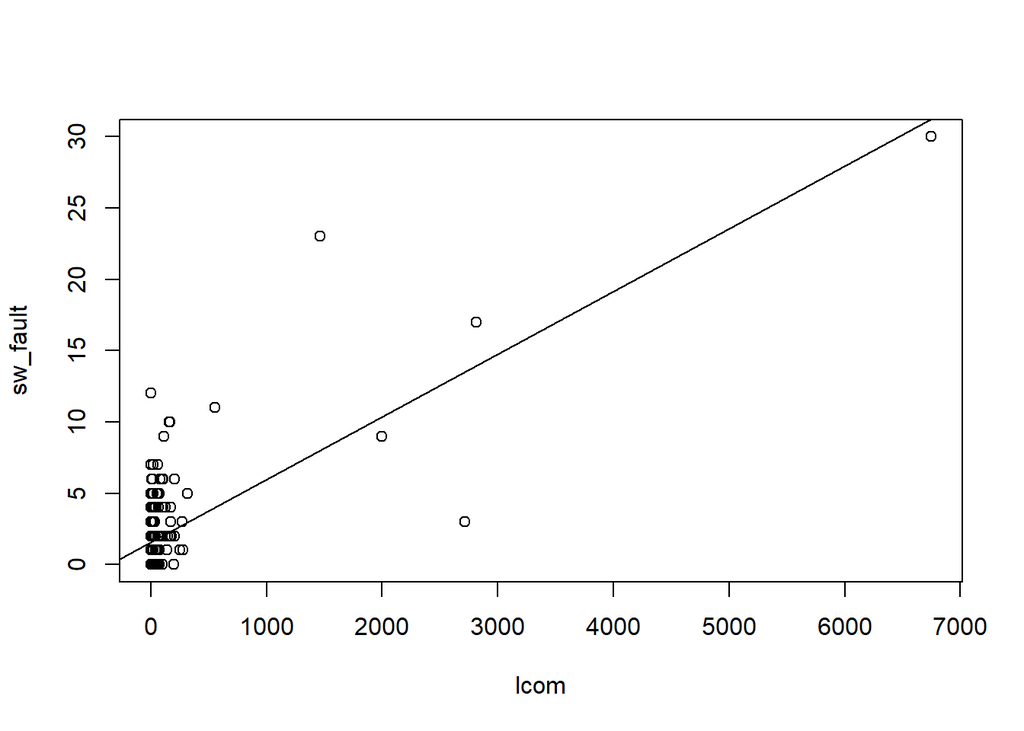

```r
sw_faultVSlcom <- lm(sw_fault~lcom)

plot(lcom, sw_fault)
abline(sw_faultVSlcom)
```

The steps performed to evaluate the results of the OLS technique applied to the variables Software Faultiness and LCOM are the same performed in the previous analysis.

### Check of the assumptions

```r
orig_corrCoeff <- correlation.coefficients(lcom, sw_fault, sw_faultVSlcom)
```

```
##
##  Pearson's product-moment correlation
##
## data:  x and y
## t = 15.914, df = 338, p-value < 2.2e-16
## alternative hypothesis: true correlation is greater than 0
## 95 percent confidence interval:
##  0.600214 1.000000
## sample estimates:
##       cor
## 0.6544725
##
##
##  Spearman's rank correlation rho
##
## data:  y and x
## S = 5325716, p-value = 0.0005286
## alternative hypothesis: true rho is not equal to 0
## sample estimates:
##       rho
## 0.1869893
##
##
##  Kendall's rank correlation tau
##
## data:  y and x
## z = 3.4799, p-value = 0.0002508
## alternative hypothesis: true tau is greater than 0
## sample estimates:
##       tau
## 0.1462129
##
##
##  Shapiro-Wilk normality test
##
## data:  ols_model$residuals
## W = 0.77572, p-value < 2.2e-16
```

```r
colnames(orig_corrCoeff) <- c('SwFaultVSLCOM')
orig_corrCoeff
```

```
##                      SwFaultVSLCOM
## Pearson's R           6.544725e-01
## Spearman's Rho        1.869893e-01
## Kendall's Tau         1.462129e-01
## Shapiro-Wilk p-value  2.904956e-21
```

According to the obtained results, the Pearson’s R coefficient shows a slight degree of correlation, but both the Spearman’s rho and the Kendall’s tau are quite near to 0. The p-value computed by the Shapiro-Wilk test is less than 0.05.

### Data transformation - Logarithmic transformation

```r
log_sw_fault <- log(1+sw_fault)
log_lcom <- log(1+lcom)

log_sw_faultVSlcom <- lm(log_sw_fault~log_lcom)
```

```r
log_corrCoeff <- correlation.coefficients(log_lcom, log_sw_fault, log_sw_faultVSlcom)
```

```
##
##  Pearson's product-moment correlation
##
## data:  x and y
## t = 6.067, df = 338, p-value = 1.747e-09
## alternative hypothesis: true correlation is greater than 0
## 95 percent confidence interval:
##  0.2304688 1.0000000
## sample estimates:
##       cor
## 0.3133767
##
##
##  Spearman's rank correlation rho
##
## data:  y and x
## S = 5325716, p-value = 0.0005286
## alternative hypothesis: true rho is not equal to 0
## sample estimates:
##       rho
## 0.1869893
##
##
##  Kendall's rank correlation tau
##
## data:  y and x
## z = 3.4799, p-value = 0.0002508
## alternative hypothesis: true tau is greater than 0
## sample estimates:
##       tau
## 0.1462129
##
##
##  Shapiro-Wilk normality test
##
## data:  ols_model$residuals
## W = 0.94647, p-value = 9.256e-10
```

```r
colnames(log_corrCoeff) <- c('Log_SwFaultVSLCOM')
log_corrCoeff
```

```
##                      Log_SwFaultVSLCOM
## Pearson's R               3.133767e-01
## Spearman's Rho            1.869893e-01
## Kendall's Tau             1.462129e-01
## Shapiro-Wilk p-value      9.256069e-10
```

According to the obtained results and with the results obtained on the original data, the results of both the Spearman’s rho and the Kendall’s tau are not changed, but the Pearson’s R is strongly decreased. Furthermore, the p-value computed by the Shapiro-Wilk test is still less than 0.05. So, this transformation did not work in this situation.

It is also possible to graphically check that the data are not linearly dependent.

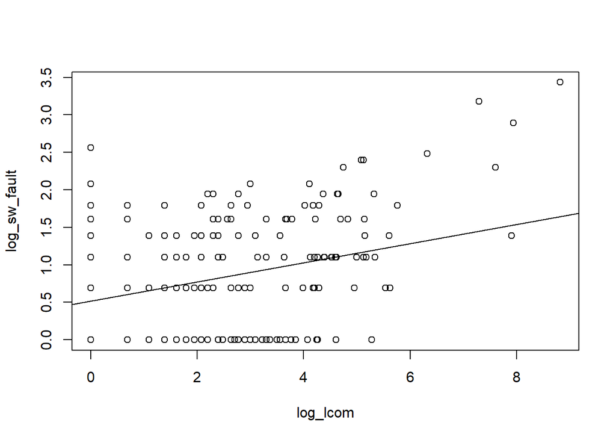

```r
plot(log_lcom, log_sw_fault)
abline(log_sw_faultVSlcom)
```

### Data transformation - Outliers Removal

```r
cooksDistances <- cooks.distance(sw_faultVSlcom)
sum(cooksDistances > 4/length(cooksDistances))
```

```
## [1] 9
```

```r
sum(cooksDistances > 1)
```

```
## [1] 1
```

Since it is preferable to remove the fewest number of data-points, the case in which the threshold equals 1 is analyzed as first.

### Data transformation - Outliers Removal - Threshold = 1

In order to remove the outliers according to a threshold value equal to 1, the same function defined before is used.

```r
nonOutliersCook1 <- removeOutliersCook1(lcom, sw_fault)
```

In order to make the code more clear, two new variables are created.

```r
nonOutliersCook1_lcom <- nonOutliersCook1[[1]]
nonOutliersCook1_sw_fault <- nonOutliersCook1[[2]]
```

Before the correlation coefficient are computed on the new data, it is important to check how many data-points has been removed.

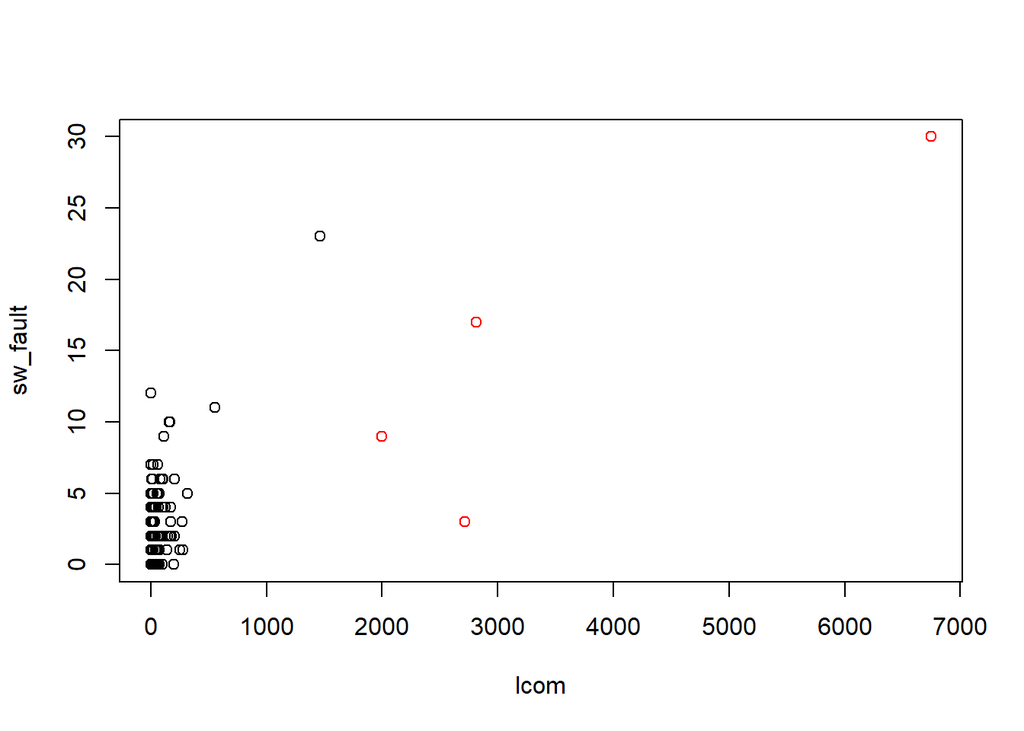

```r
plot(lcom, sw_fault, col="red")
points(nonOutliersCook1_lcom, nonOutliersCook1_sw_fault, col="black")
```

The model is finally re-created and the OLS assumptions are checked on the data with the outliers removed.

```r
nonOutliersCook1_sw_faultsVSlcom <- lm(nonOutliersCook1_sw_fault~nonOutliersCook1_lcom)

nonOutliersCook1_corrCoeff <- correlation.coefficients(nonOutliersCook1_lcom,
                                                        nonOutliersCook1_sw_fault,
                                                        nonOutliersCook1_sw_faultsVSlcom)
```

```
##
##  Pearson's product-moment correlation
##
## data:  x and y
## t = 12.742, df = 334, p-value < 2.2e-16
## alternative hypothesis: true correlation is greater than 0
## 95 percent confidence interval:
##  0.5081443 1.0000000
## sample estimates:
##       cor
## 0.5719139
##
##
##  Spearman's rank correlation rho
##
## data:  y and x
## S = 5314923, p-value = 0.00341
## alternative hypothesis: true rho is not equal to 0
## sample estimates:
##       rho
## 0.1593132
##
##
##  Kendall's rank correlation tau
##
## data:  y and x
## z = 2.9318, p-value = 0.001685
## alternative hypothesis: true tau is greater than 0
## sample estimates:
##       tau
## 0.1242983
##
##
##  Shapiro-Wilk normality test
##
## data:  ols_model$residuals
## W = 0.84712, p-value < 2.2e-16
```

```r
colnames(nonOutliersCook1_corrCoeff) <- c('NonOutCook1_SwFaultVSLCOM')
nonOutliersCook1_corrCoeff
```

```
##                      NonOutCook1_SwFaultVSLCOM
## Pearson's R                       5.719139e-01
## Spearman's Rho                    1.593132e-01
## Kendall's Tau                     1.242983e-01
## Shapiro-Wilk p-value              1.351111e-17
```

According to the obtained results and with the results obtained on the original data, the Pearson’s R coefficient is slightly decreased, but still significant. However, both the Spearman’s rho and the Kendall’s tau are quite near to 0. Furthermore, the p-value computed by the Shapiro-Wilk test is still less than 0.05. So, this transformation did not work in this situation.

It is also possible to graphically check the differences between the two OLS lines of regression.

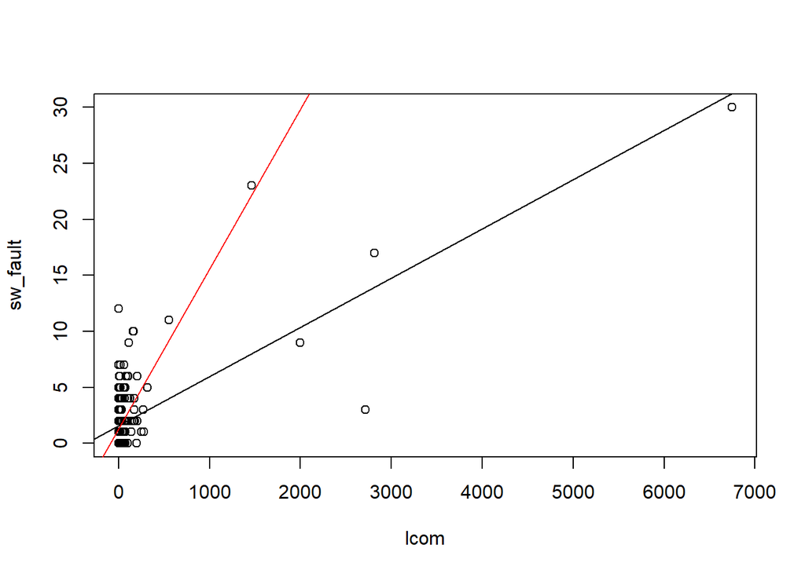

```r
plot(lcom, sw_fault)
abline(sw_faultVSlcom)
abline(nonOutliersCook1_sw_faultsVSlcom, col="red")
```

### Data transformation - Outliers Removal - Threshold = 4/L

In order to remove the outliers according to a threshold value equal to 4/L, the same function defined before is used.

```r
nonOutliersCook4l <- removeOutliersCook4l(lcom, sw_fault)
```

In order to make the code more clear, two new variables are created.

```r
nonOutliersCook4l_lcom <- nonOutliersCook4l[[1]]
nonOutliersCook4l_sw_fault <- nonOutliersCook4l[[2]]
```

Before the correlation coefficient are computed on the new data, it is important to check how many data-points has been removed.

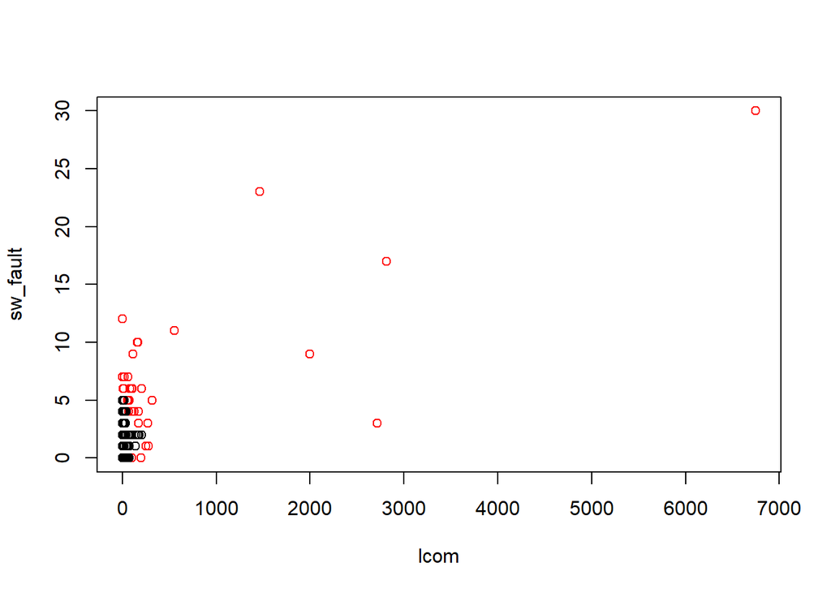

```r
plot(lcom, sw_fault, col="red")
points(nonOutliersCook4l_lcom, nonOutliersCook4l_sw_fault, col="black")
```

It can be usefut to print the number of data-points that have been removed from the function.

```r
cat("Data-points in the original data:",
    length(sw_fault))
```

```
## Data-points in the original data: 340
```

```r
cat("Data-points removed from the original data:",
    length(sw_fault) - length(nonOutliersCook4l_sw_fault))
```

```
## Data-points removed from the original data: 36
```

The model is finally re-created and the OLS assumptions are checked on the data with the outliers removed.

```r
nonOutliersCook4l_sw_faultsVSlcom <- lm(nonOutliersCook4l_sw_fault~nonOutliersCook4l_lcom)

nonOutliersCook4l_corrCoeff <- correlation.coefficients(nonOutliersCook4l_lcom,
                                                        nonOutliersCook4l_sw_fault,
                                                        nonOutliersCook4l_sw_faultsVSlcom)
```

```
##
##  Pearson's product-moment correlation
##
## data:  x and y
## t = 1.1573, df = 302, p-value = 0.124
## alternative hypothesis: true correlation is greater than 0
## 95 percent confidence interval:
##  -0.02825576  1.00000000
## sample estimates:
##        cor
## 0.06644645
##
##
##  Spearman's rank correlation rho
##
## data:  y and x
## S = 4554947, p-value = 0.6365
## alternative hypothesis: true rho is not equal to 0
## sample estimates:
##        rho
## 0.02721129
##
##
##  Kendall's rank correlation tau
##
## data:  y and x
## z = 0.48175, p-value = 0.315
## alternative hypothesis: true tau is greater than 0
## sample estimates:
##        tau
## 0.02194179
##
##
##  Shapiro-Wilk normality test
##
## data:  ols_model$residuals
## W = 0.80526, p-value < 2.2e-16
```

```r
colnames(nonOutliersCook4l_corrCoeff) <- c('NonOutCook4l_SwFaultVSLCOM')
nonOutliersCook4l_corrCoeff
```

```
##                      NonOutCook4l_SwFaultVSLCOM
## Pearson's R                        6.644645e-02
## Spearman's Rho                     2.721129e-02
## Kendall's Tau                      2.194179e-02
## Shapiro-Wilk p-value               8.315815e-19
```

Comparing the obtained results with the ones obtained on the original data, all the results show worse results. In particular, all the values of the correlation coefficients are very near to 0. The p-value computed by the Shapiro-Wilk test is still less than 0.05. So, this transformation did not work in this situation.

It is also possible to graphically check the differences between the two OLS lines of regression.

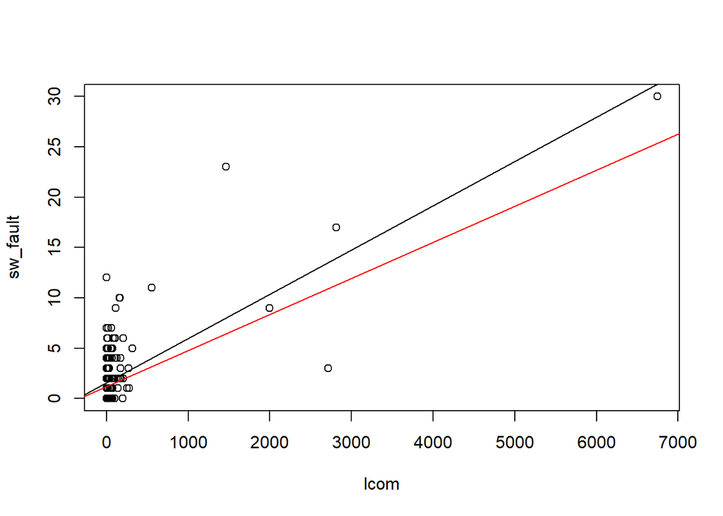

```r
plot(lcom, sw_fault)
abline(sw_faultVSlcom)
abline(nonOutliersCook4l_sw_faultsVSlcom, col="red")
```

### Final considerations

The application of the OLS technique on the variables LCOM and Software Faultiness is not possible, because these two variables are not linearly dependent.

In particular, it is possible to report the main coefficient that evaluate the linear dependency of these two variables over the different analysis performed.

```r
cbind(orig_corrCoeff, log_corrCoeff, nonOutliersCook1_corrCoeff, nonOutliersCook4l_corrCoeff)
```

```
##                      SwFaultVSLCOM Log_SwFaultVSLCOM NonOutCook1_SwFaultVSLCOM
## Pearson's R           6.544725e-01      3.133767e-01              5.719139e-01
## Spearman's Rho        1.869893e-01      1.869893e-01              1.593132e-01
## Kendall's Tau         1.462129e-01      1.462129e-01              1.242983e-01
## Shapiro-Wilk p-value  2.904956e-21      9.256069e-10              1.351111e-17
##                      NonOutCook4l_SwFaultVSLCOM
## Pearson's R                        6.644645e-02
## Spearman's Rho                     2.721129e-02
## Kendall's Tau                      2.194179e-02
## Shapiro-Wilk p-value               8.315815e-19
```

Looking at the above table, it is possible to state that both the original data and the ones where the outliers are removed according to a threshold value equal to 1 show a slight degree of correlation. However, in both these cases, both the Spearman’s rho and the Kendall’s tau are quite near to 0 and the p-value computed by the Shapiro-Wilk test is always less than 0.05.

## Univariate statistically-significant model - OLS - Results evaluation

Looking at the results obtained through the application of the OLS technique to all the pairs of independent-dependent variables, it is possible to state that a statistically-significant model is never built-up using OLS.

# Univariate statistically-significant model - Binary Logistic Regression

The Binary Logistic Regression is a statistical technique used to predict the relationship between one or more independent variables and a the dependent one, where the dependent variable can only assume two possible values.

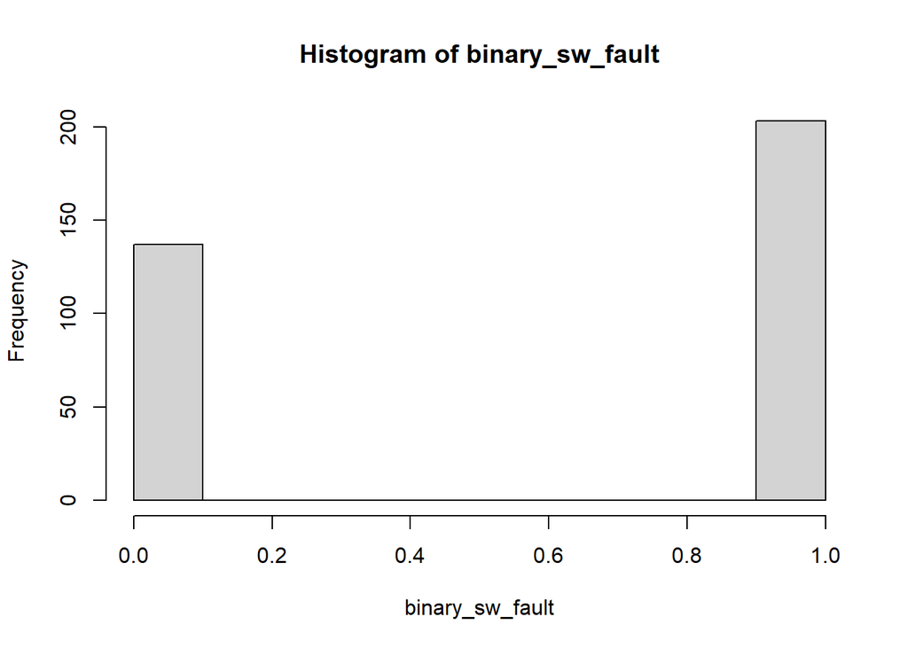

```r
binary_sw_fault <- ifelse(sw_fault > 0, 1, 0)
hist(binary_sw_fault)
```

In particular, the dependent variable is transformed in such a way that it can only assume the values 1 when the data-point is considered as a faulty artifact or 0 when the data-point is considered as a non-faulty artifact.

## Univariate statistically-significant model - Binary Logistic Regression - Software Faultiness vs LOC

It can be useful to plot how both the faulty and non-faulty data-points are distributed with respect to the LOC variable.

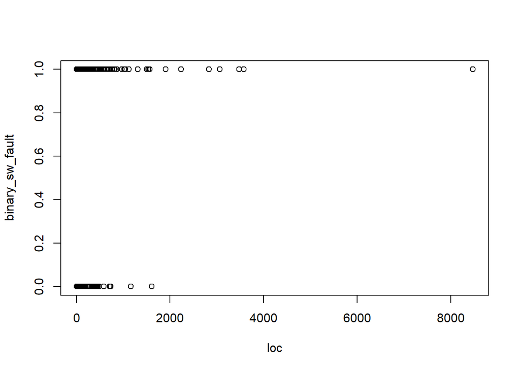

```r
plot(loc, binary_sw_fault)
```

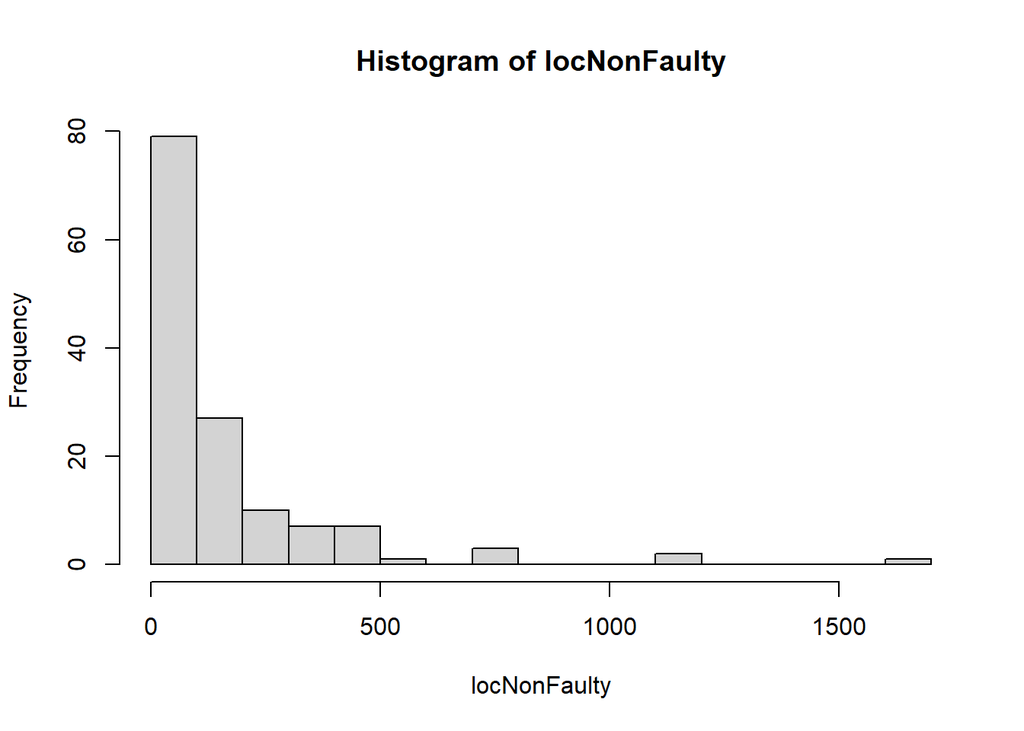

```r
locNonFaulty <- loc[binary_sw_fault %in% 0]
hist(locNonFaulty, breaks = 20)
```

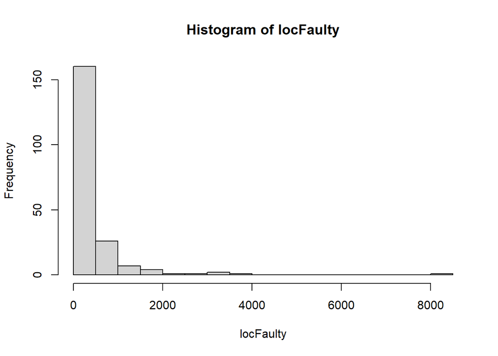

```r
locFaulty <- loc[binary_sw_fault %in% 1]
hist(locFaulty, breaks = 20)
```

Then, the model is built-up.

```r
binary_sw_faultVSloc <- glm( binary_sw_fault~loc, family=binomial(link="logit"))
summary(binary_sw_faultVSloc)
```

```
##
## Call:
## glm(formula = binary_sw_fault ~ loc, family = binomial(link = "logit"))
##
## Deviance Residuals:
##     Min       1Q   Median       3Q      Max
## -2.4709  -1.1908   0.7597   1.0972   1.1925
##
## Coefficients:
##               Estimate Std. Error z value Pr(>|z|)
## (Intercept) -0.0372196  0.1469234  -0.253  0.80002
## loc          0.0018950  0.0004999   3.791  0.00015 ***
## ---
## Signif. codes:  0 '***' 0.001 '**' 0.01 '*' 0.05 '.' 0.1 ' ' 1
##
## (Dispersion parameter for binomial family taken to be 1)
##
##     Null deviance: 458.45  on 339  degrees of freedom
## Residual deviance: 434.08  on 338  degrees of freedom
## AIC: 438.08
##
## Number of Fisher Scoring iterations: 5
```

### Binary Logistic Regression - Software Faultiness vs LOC - Fault-proneness model

After the Binary Logistic Regression model is built-up, it can be used as a fault-proneness model in order to estimate the probability of an artifact to be faulty.

In particular, the first step involves the graphical plot of the model.

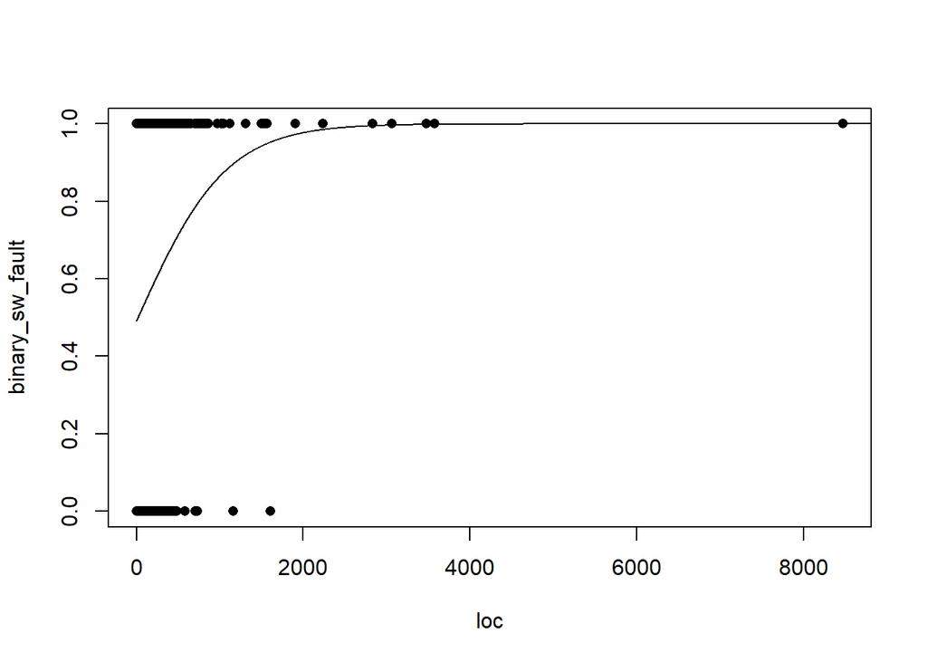

```r
xweight <- seq(min(loc), max(loc)*1.1, 0.1)
yweight <- predict(binary_sw_faultVSloc, list(loc = xweight), type="response")
plot(loc, binary_sw_fault, pch = 16, xlab = "loc", ylab = "binary_sw_fault")
lines(xweight, yweight)
```

It is also needed the definition of thresholds in addition to fault-proneness model. In particular, concerning the Software Faultiness variable, the threshold is set to the proportion of faulty data-points. Concerning the LOC variable, the threshold is set to the difference between the log odds of an artifact to be faulty according to the faulty proportion and the log odds of an artifact to be faulty according to the LOC variable.

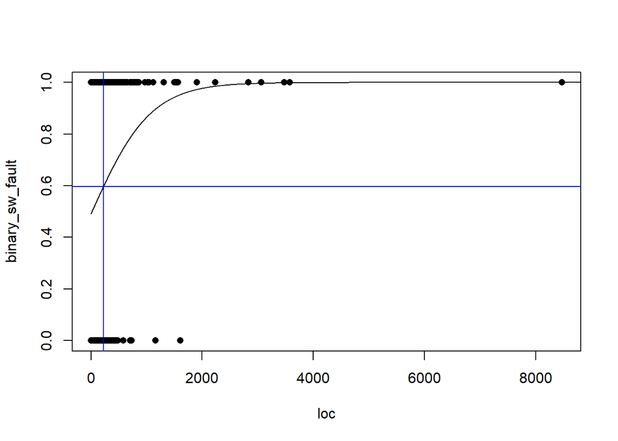

```r
# In order to plot the threshold values, it is needed to re-create the scatterplot
plot(loc, binary_sw_fault, pch = 16, xlab = "loc", ylab = "binary_sw_fault")
lines(xweight, yweight)
# Computation and plot of the threshold values
faultyProportion <- sum(binary_sw_fault)/length(binary_sw_fault)
abline(h=faultyProportion, col="blue")

x <- (log(faultyProportion/(1-faultyProportion))-
        coef(binary_sw_faultVSloc)[1])/coef(binary_sw_faultVSloc)[2]
abline(v = x, col="blue")
```

In order to evaluate the performances of the classifier, it is needed to compute the contingency table.

```r
estimatedFaulty <- binary_sw_faultVSloc$fitted.values > faultyProportion
actualFaulty <- binary_sw_fault == 1
contingencyTable <- table(estimatedFaulty, actualFaulty)
contingencyTable
```

```
##                actualFaulty
## estimatedFaulty FALSE TRUE
##           FALSE   107  118
##           TRUE     30   85
```

Given the contingency table, it is possible to compute the accuracy, precision and recall. In particular,

- The accuracy represents the proportion of correct classifications, and it is computed as ratio between the number of correct predictions and the number of samples.
- The precision represents the proportion of estimated positives that are actually positive, and it is computed as the ratio between the number of true positives and the number of estimated positives.
- The recall represents the proportion of actual positives that are also estimated as positives, and it is computed as the ratio between the number of true positives and the number of actual positives.

In particular, it can be useful to define a function that computes these coefficients according to the contingency table.

```r
accurIndNames <- c('Accuracy', 'Precision', 'Recall')

accuracy.indicators <- function(contingencyTable) {
  accuracy <- (contingencyTable[1,1]+contingencyTable[2,2])/sum(contingencyTable)
  precision <- contingencyTable[2,2]/sum(contingencyTable[2,])
  recall <- contingencyTable[2,2]/sum(contingencyTable[,2])
  matrix <- matrix(c(accuracy, precision, recall), byrow=TRUE)
  rownames(matrix) <- accurIndNames
  return (as.table(matrix))
}
```

Then, the function is called to compute the accuracy indicators of the model.

```r
accurInd <- accuracy.indicators(contingencyTable)
colnames(accurInd) <- c('SwFaultVSLOC')
round(accurInd,2)
```

```
##           SwFaultVSLOC
## Accuracy          0.56
## Precision         0.74
## Recall            0.42
```

According to the obtained results, the model does not show very good values of accuracy. In particular, the recall value equals 0.42 and the accuracy value equals 0.56. However, the model shows a very good value of precision, meaning that it is quite able to recognize faulty artifacts. Furthermore, since the model works using just an independent variable as predictor, these result can be considered as acceptable ones.

## Univariate statistically-significant model - Binary Logistic Regression - Software Faultiness vs AMC

It can be useful to plot how both the faulty and non-faulty data-points are distributed with respect to the AMC variable.

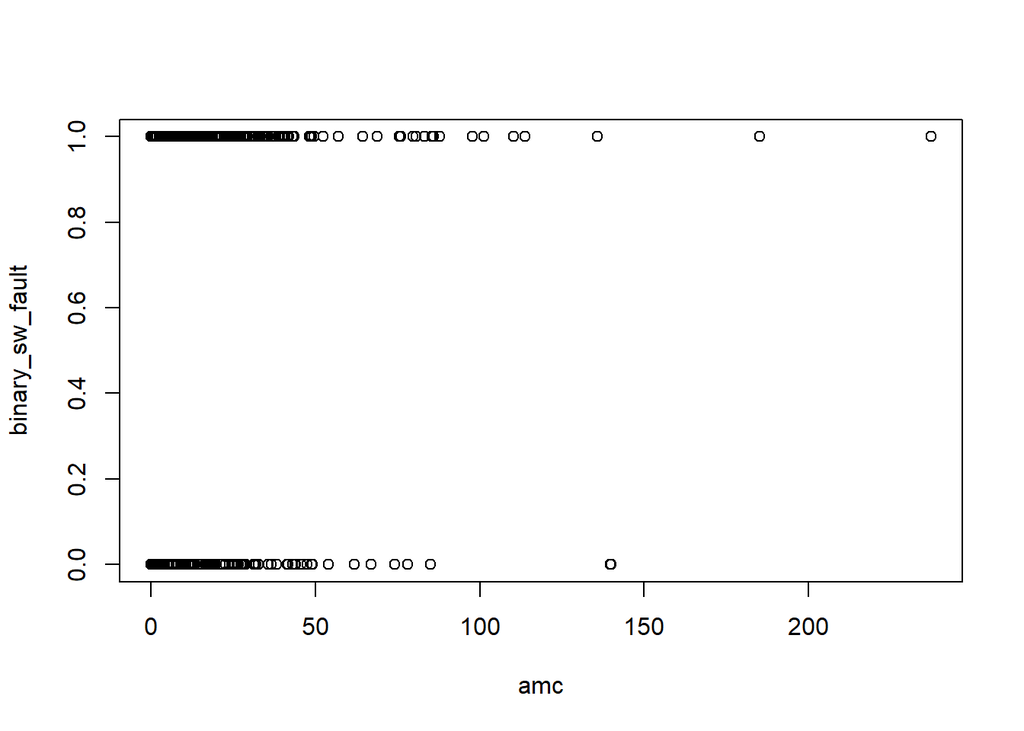

```r
plot(amc, binary_sw_fault)
```

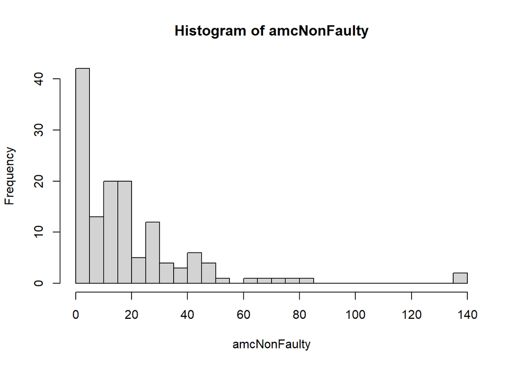

```r
amcNonFaulty <- amc[binary_sw_fault %in% 0]
hist(amcNonFaulty, breaks = 20)
```

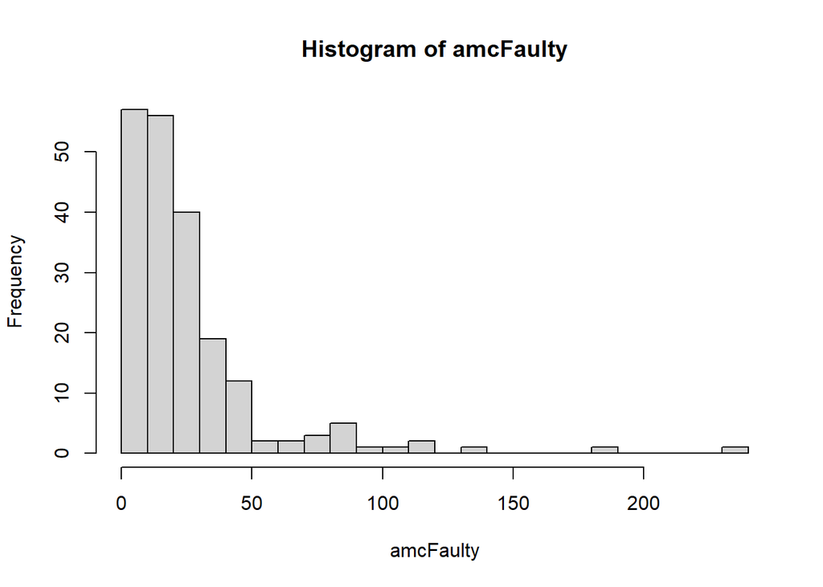

```r
amcFaulty <- amc[binary_sw_fault %in% 1]
hist(amcFaulty, breaks = 20)
```

Then, the model is built-up.

```r
binary_sw_faultVSamc <- glm( binary_sw_fault~amc, family=binomial(link="logit"))
summary(binary_sw_faultVSamc)
```

```
##
## Call:
## glm(formula = binary_sw_fault ~ amc, family = binomial(link = "logit"))
##
## Deviance Residuals:
##     Min       1Q   Median       3Q      Max
## -1.9182  -1.2871   0.9438   1.0428   1.1117
##
## Coefficients:
##             Estimate Std. Error z value Pr(>|z|)
## (Intercept) 0.156625   0.152703   1.026   0.3050
## amc         0.010787   0.005045   2.138   0.0325 *
## ---
## Signif. codes:  0 '***' 0.001 '**' 0.01 '*' 0.05 '.' 0.1 ' ' 1
##
## (Dispersion parameter for binomial family taken to be 1)
##
##     Null deviance: 458.45  on 339  degrees of freedom
## Residual deviance: 453.03  on 338  degrees of freedom
## AIC: 457.03
##
## Number of Fisher Scoring iterations: 4
```

### Binary Logistic Regression - Software Faultiness vs AMC - Fault-proneness model

After the Binary Logistic Regression model is built-up, it can be used as a fault-proneness model in order to estimate the probability of an artifact to be faulty.

In particular, the first step involves the graphical plot of the model.

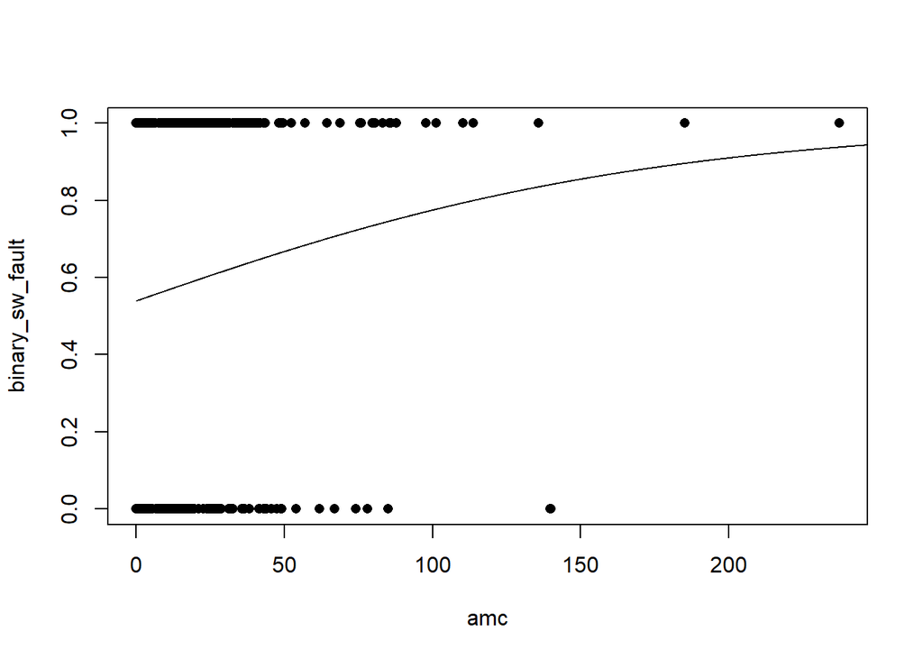

```r
xweight <- seq(min(amc), max(amc)*1.1, 0.1)
yweight <- predict(binary_sw_faultVSamc, list(amc = xweight), type="response")
plot(amc, binary_sw_fault, pch = 16, xlab = "amc", ylab = "binary_sw_fault")
lines(xweight, yweight)
```

Then, the threshold values need to be computed.

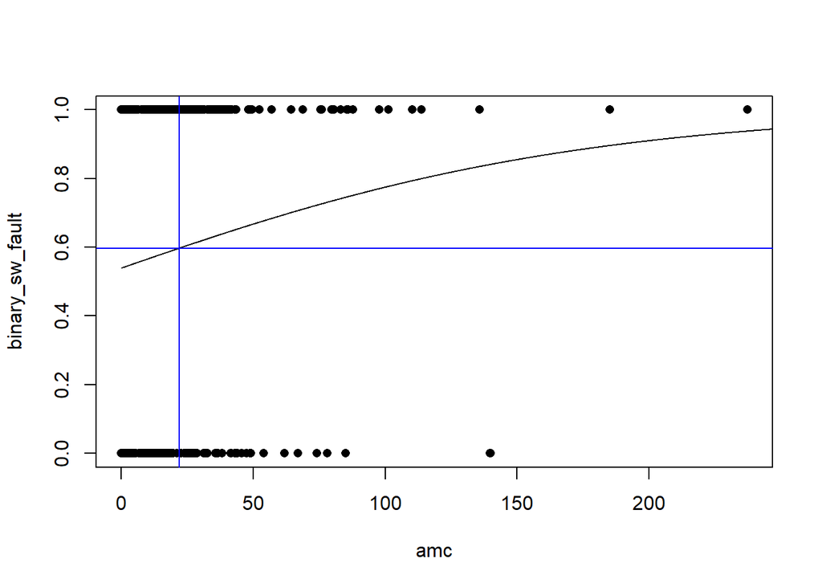

```r
# In order to plot the threshold values, it is needed to re-create the scatterplot
plot(amc, binary_sw_fault, pch = 16, xlab = "amc", ylab = "binary_sw_fault")
lines(xweight, yweight)
# Computation and plot of the threshold values
faultyProportion <- sum(binary_sw_fault)/length(binary_sw_fault)
abline(h=faultyProportion, col="blue")

x <- (log(faultyProportion/(1-faultyProportion))-
        coef(binary_sw_faultVSamc)[1])/coef(binary_sw_faultVSamc)[2]
abline(v = x, col="blue")
```

In order to evaluate the performances of the classifier, it is needed to compute the contingency table.

```r
estimatedFaulty <- binary_sw_faultVSamc$fitted.values > faultyProportion
actualFaulty <- binary_sw_fault == 1
contingencyTable <- table(estimatedFaulty, actualFaulty)
contingencyTable
```

```
##                actualFaulty
## estimatedFaulty FALSE TRUE
##           FALSE    96  119
##           TRUE     41   84
```

Finally, the previously-defined function is called to compute the accuracy indicators of the model.

```r
accurInd <- accuracy.indicators(contingencyTable)
colnames(accurInd) <- c('SwFaultVSAMC')
round(accurInd, 2)
```

```
##           SwFaultVSAMC
## Accuracy          0.53
## Precision         0.67
## Recall            0.41
```

According to the obtained results, the model shows the accuracy values to be slightly worse than the ones obtained using the LOC variable as predictor. However, even in this case the results can be considered as quite good ones.

## Univariate statistically-significant model - Binary Logistic Regression - Software Faultiness vs MOA

It can be useful to plot how both the faulty and non-faulty data-points are distributed with respect to the MOA variable.

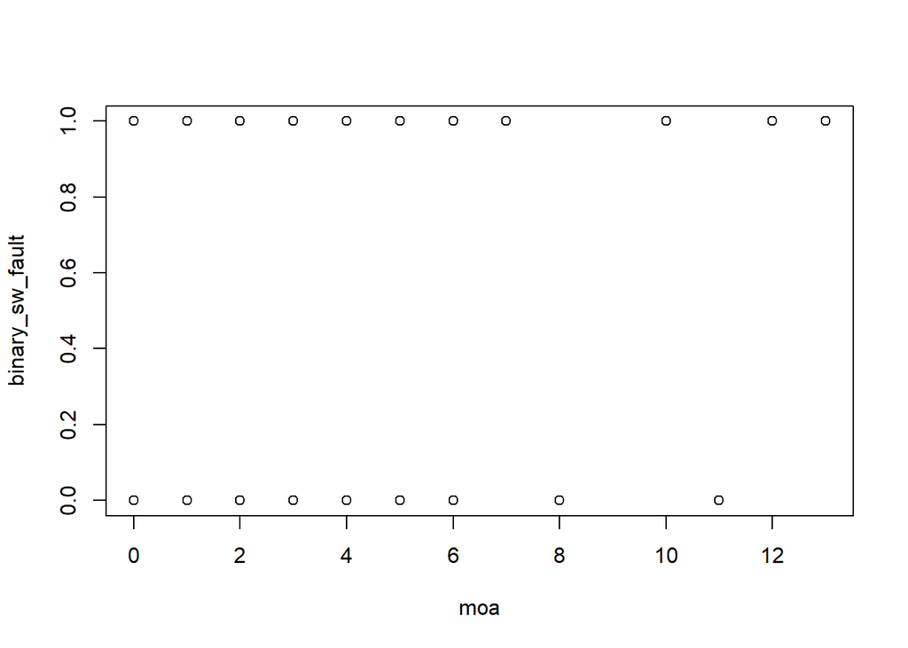

```r
plot(moa, binary_sw_fault)
```

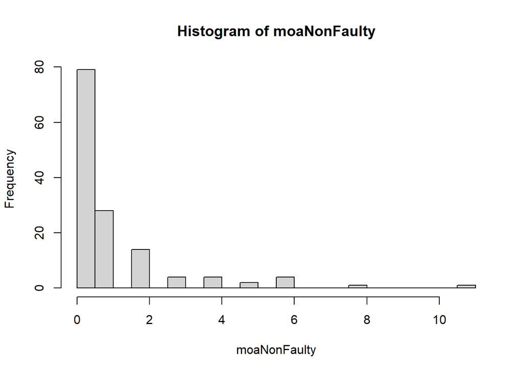

```r
moaNonFaulty <- moa[binary_sw_fault %in% 0]
hist(moaNonFaulty, breaks = 20)
```

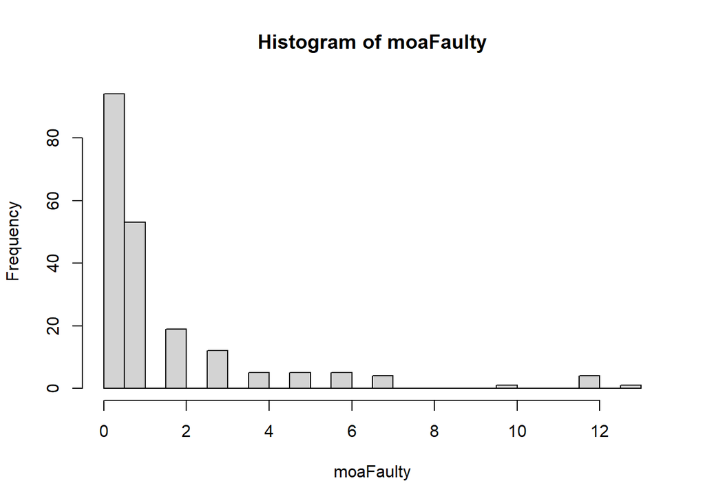

```r
moaFaulty <- moa[binary_sw_fault %in% 1]
hist(moaFaulty, breaks = 20)
```

Then, the model is built-up.

```r
binary_sw_faultVSmoa <- glm( binary_sw_fault~moa, family=binomial(link="logit"))
summary(binary_sw_faultVSmoa)
```

```
##
## Call:
## glm(formula = binary_sw_fault ~ moa, family = binomial(link = "logit"))
##
## Deviance Residuals:
##     Min       1Q   Median       3Q      Max
## -1.8343  -1.2891   0.9389   1.0697   1.0697
##
## Coefficients:
##             Estimate Std. Error z value Pr(>|z|)
## (Intercept)  0.25871    0.12870   2.010   0.0444 *
## moa          0.11072    0.05741   1.929   0.0538 .
## ---
## Signif. codes:  0 '***' 0.001 '**' 0.01 '*' 0.05 '.' 0.1 ' ' 1
##
## (Dispersion parameter for binomial family taken to be 1)
##
##     Null deviance: 458.45  on 339  degrees of freedom
## Residual deviance: 454.28  on 338  degrees of freedom
## AIC: 458.28
##
## Number of Fisher Scoring iterations: 4
```

### Binary Logistic Regression - Software Faultiness vs MOA - Fault-proneness model

After the Binary Logistic Regression model is built-up, it can be used as a fault-proneness model in order to estimate the probability of an artifact to be faulty.

In particular, the first step involves the graphical plot of the model.

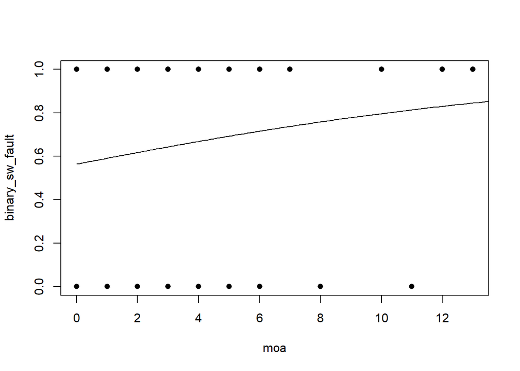

```r
xweight <- seq(min(moa), max(moa)*1.1, 0.1)
yweight <- predict(binary_sw_faultVSmoa, list(moa = xweight), type="response")
plot(moa, binary_sw_fault, pch = 16, xlab = "moa", ylab = "binary_sw_fault")
lines(xweight, yweight)
```

Then, the threshold values need to be computed.

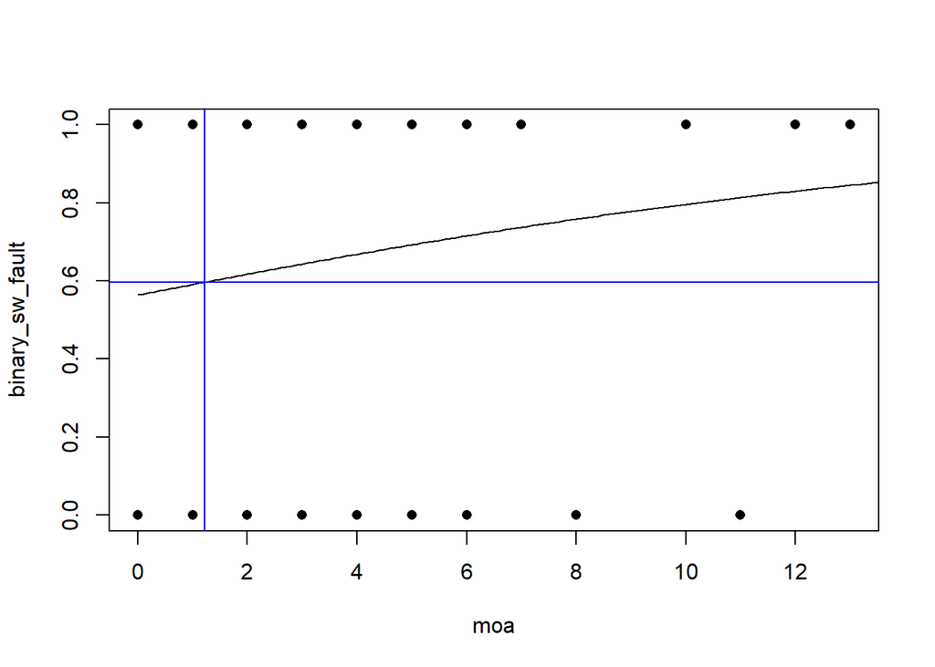

```r
# In order to plot the threshold values, it is needed to re-create the scatterplot
plot(moa, binary_sw_fault, pch = 16, xlab = "moa", ylab = "binary_sw_fault")
lines(xweight, yweight)
# Computation and plot of the threshold values
faultyProportion <- sum(binary_sw_fault)/length(binary_sw_fault)
abline(h=faultyProportion, col="blue")

x <- (log(faultyProportion/(1-faultyProportion))-
        coef(binary_sw_faultVSmoa)[1])/coef(binary_sw_faultVSmoa)[2]
abline(v = x, col="blue")
```

In order to evaluate the performances of the classifier, it is needed to compute the contingency table.

```r
estimatedFaulty <- binary_sw_faultVSmoa$fitted.values > faultyProportion
actualFaulty <- binary_sw_fault == 1
contingencyTable <- table(estimatedFaulty, actualFaulty)
contingencyTable
```

```
##                actualFaulty
## estimatedFaulty FALSE TRUE
##           FALSE   107  147
##           TRUE     30   56
```

Finally, the previously-defined function is called to compute the accuracy indicators of the model.

```r
accurInd <- accuracy.indicators(contingencyTable)
colnames(accurInd) <- c('SwFaultVSMOA')
round(accurInd, 2)
```

```
##           SwFaultVSMOA
## Accuracy          0.48
## Precision         0.65
## Recall            0.28
```

According to the obtained results, the model shows the accuracy values to be slightly worse than the ones obtained in the previous analysis. In particular, these results cannot be considered as good ones.

## Univariate statistically-significant model - Binary Logistic Regression - Software Faultiness vs LCOM

It can be useful to plot how both the faulty and non-faulty data-points are distributed with respect to the LCOM variable.

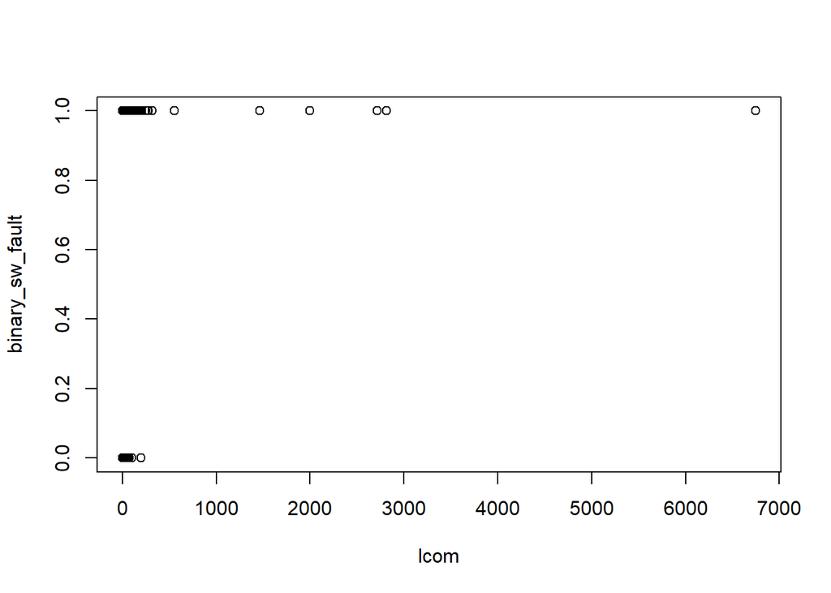

```r
plot(lcom, binary_sw_fault)
```

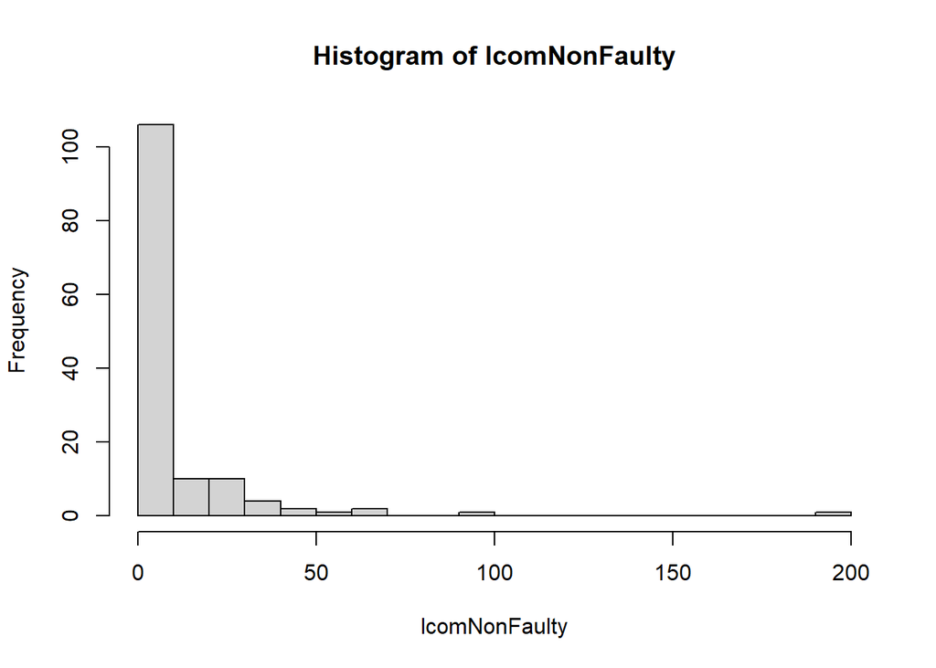

```r
lcomNonFaulty <- lcom[binary_sw_fault %in% 0]
hist(lcomNonFaulty, breaks = 20)
```

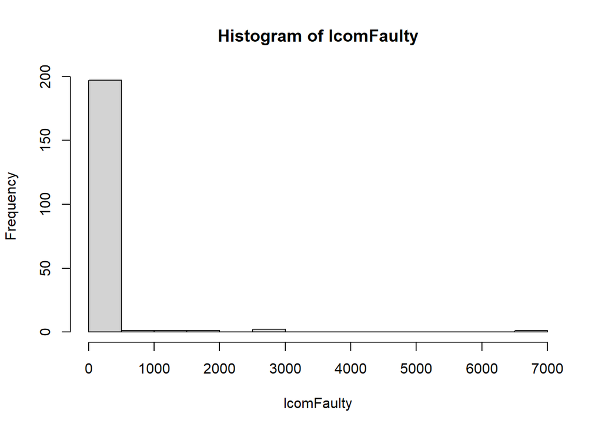

```r
lcomFaulty <- lcom[binary_sw_fault %in% 1]
hist(lcomFaulty, breaks = 20)
```

Then, the model is built-up.

```r
binary_sw_faultVSlcom <- glm( binary_sw_fault~lcom, family=binomial(link="logit"))
summary(binary_sw_faultVSlcom)
```

```
##
## Call:
## glm(formula = binary_sw_fault ~ lcom, family = binomial(link = "logit"))
##
## Deviance Residuals:
##    Min      1Q  Median      3Q     Max
## -2.437  -1.239   0.727   1.111   1.123
##
## Coefficients:
##             Estimate Std. Error z value Pr(>|z|)
## (Intercept) 0.128740   0.125131   1.029 0.303555
## lcom        0.014231   0.004288   3.319 0.000905 ***
## ---
## Signif. codes:  0 '***' 0.001 '**' 0.01 '*' 0.05 '.' 0.1 ' ' 1
##
## (Dispersion parameter for binomial family taken to be 1)
##
##     Null deviance: 458.45  on 339  degrees of freedom
## Residual deviance: 434.26  on 338  degrees of freedom
## AIC: 438.26
##
## Number of Fisher Scoring iterations: 8
```

### Binary Logistic Regression - Software Faultiness vs LCOM - Fault-proneness model

After the Binary Logistic Regression model is built-up, it can be used as a fault-proneness model in order to estimate the probability of an artifact to be faulty.

In particular, the first step involves the graphical plot of the model.

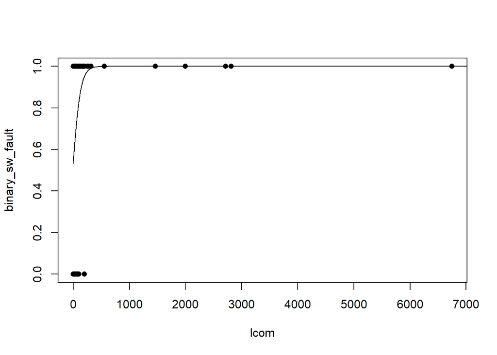

```r
xweight <- seq(min(lcom), max(lcom)*1.1, 0.1)
yweight <- predict(binary_sw_faultVSlcom, list(lcom = xweight), type="response")
plot(lcom, binary_sw_fault, pch = 16, xlab = "lcom", ylab = "binary_sw_fault")
lines(xweight, yweight)
```

Then, the threshold values need to be computed.

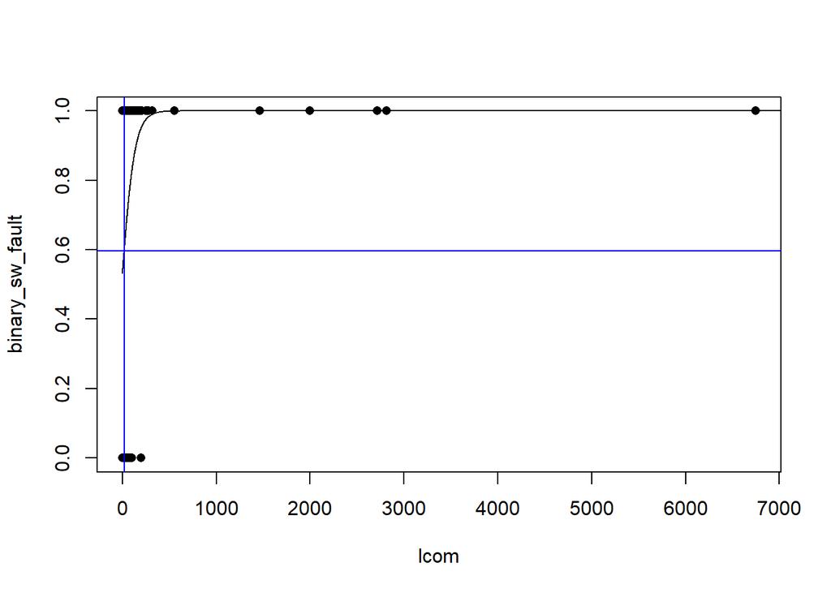

```r
# In order to plot the threshold values, it is needed to re-create the scatterplot
plot(lcom, binary_sw_fault, pch = 16, xlab = "lcom", ylab = "binary_sw_fault")
lines(xweight, yweight)
# Computation and plot of the threshold values
faultyProportion <- sum(binary_sw_fault)/length(binary_sw_fault)
abline(h=faultyProportion, col="blue")

x <- (log(faultyProportion/(1-faultyProportion))-
        coef(binary_sw_faultVSlcom)[1])/coef(binary_sw_faultVSlcom)[2]
abline(v = x, col="blue")
```

In order to evaluate the performances of the classifier, it is needed to compute the contingency table.

```r
estimatedFaulty <- binary_sw_faultVSlcom$fitted.values > faultyProportion
actualFaulty <- binary_sw_fault == 1
contingencyTable <- table(estimatedFaulty, actualFaulty)
contingencyTable
```

```
##                actualFaulty
## estimatedFaulty FALSE TRUE
##           FALSE   115  145
##           TRUE     22   58
```

Finally, the previously-defined function is called to compute the accuracy indicators of the model.

```r
accurInd <- accuracy.indicators(contingencyTable)
colnames(accurInd) <- c('SwFaultVSLCOM')
round(accurInd, 2)
```

```
##           SwFaultVSLCOM
## Accuracy           0.51
## Precision          0.72
## Recall             0.29
```

According to the obtained results, the model shows the accuracy values to be slightly worse than the ones obtained using the LOC variable or the AMC variable as predictors. However, even in this case the results can be considered as quite good ones.

## Univariate statistically-significant model - Binary Logistic Regression - Results evaluation

Looking at the results obtained through the application of the Binary Logistic Regression with a single predictor, the variable that allows to obtain the best accuracy result is the LOC. In particular, in this case the model reaches an accuracy of 56% and a precision of 74%. Since only one variable is used to predict the label of the new data, this result can be considered as a good one. It is also possible to notice that even the independent variables AMC and LCOM allow to obtain a model with acceptable performances.

# Multivariate statistically-significant model - Naive Bayes Classifier

Naive Bayes is a Supervised Machine Learning algorithm based on the Bayes Theorem, and it is used to solve classification problems by following a probabilistic approach. It is based on the idea that the independent variables in a Machine Learning model are independent of each other. Meaning that the outcome of a model depends on a set of independent variables that have nothing to do with each other.

According to the results obtained while checking the assumptions of the OLS technique, the Software Faultiness variable is more correlated with the variables LOC and LCOM. For this reason, it has been chosen to start to evaluate the accuracy of a Naive Bayes Classifier that used these two variables as the predictors.

In order to build up a Naive Bayes Classifier, a dataframe structure is required.

```r
cleanedLucene <- lucene[c("bug","loc","amc","moa","lcom")]
```

Furthermore, it is needed to transform the dependent variable into a categorical one. In particular, the Software Faultiness’s values will be ‘Faulty’ or ‘Non-Faulty’ based on its original value.

```r
bug <- lucene$bug
binary_bug <- ifelse(bug > 0, 'Faulty', 'Non-Faulty')
cleanedLucene[["bug"]] <- binary_bug
head(cleanedLucene)
```

|  | bug | loc | amc | moa | lcom |
| --- | --- | --- | --- | --- | --- |
| 1 | Faulty | 84 | 14.40 | 7 | 0 |
| 2 | Faulty | 286 | 27.20 | 0 | 7 |
| 3 | Non-Faulty | 287 | 27.50 | 0 | 0 |
| 4 | Non-Faulty | 26 | 5.50 | 0 | 6 |
| 5 | Faulty | 596 | 22.36 | 5 | 160 |
| 6 | Non-Faulty | 8 | 0.60 | 0 | 10 |

### Check of the assumptions

The Naive Bayes Classifiers requires the independent variables to be independent with each other. In order to evaluate the degree of correlation among all the independent variables, the correlation matrix is computed.

```r
indep_var <- cleanedLucene[,-1]
corr_matr <- cor(indep_var)
round(corr_matr, 2)
```

```
##       loc  amc  moa lcom
## loc  1.00 0.48 0.49 0.78
## amc  0.48 1.00 0.20 0.06
## moa  0.49 0.20 1.00 0.42
## lcom 0.78 0.06 0.42 1.00
```

Looking at the correlation matrix, the only pairs of variables that do not share a considerable degree of correlation are AMC-LCOM and AMC-MOA. So, these pairs of variables are the ones that will be analyzed as first.

## Naive Bayes Classifier - Software Faultiness vs AMC and LCOM

For sake of reproducibility, it is needed to set the value of the seed of the random number generator.

```r
set.seed(123456)
```

Furthermore, it is needed to import some useful libraries. The first one contains functions to streamline the model training process for complex regression and classification problems. The second one contains the functions used to create several well-known classification models.

```r
library(caret)
library(e1071)
```

The following step involves the creation of both the training and the test sets.

```r
trainIndex <- createDataPartition(cleanedLucene$bug, p=0.7)$Resample1
training <- cleanedLucene[trainIndex, ]
testing <- cleanedLucene[-trainIndex, ]
```

It is also possible to show some interesting characteristics of these two sets of data-points.

```r
cat("Number of data-points in the training set:", length(training$bug))
```

```
## Number of data-points in the training set: 239
```

```r
cat("Number of data-points in the test set:", length(testing$bug))
```

```
## Number of data-points in the test set: 101
```

```r
cat("Number of Faulty and Non-Faulty data-points in the training set:",
    table(training$bug))
```

```
## Number of Faulty and Non-Faulty data-points in the training set: 143 96
```

```r
cat("Number of Faulty and Non-Faulty data-points in the test set:",
    table(testing$bug))
```

```
## Number of Faulty and Non-Faulty data-points in the test set: 60 41
```

```r
cat("Proportion of Faulty and Non-Faulty data-points in the training set:",
    prop.table(table(training$bug)) * 100)
```

```
## Proportion of Faulty and Non-Faulty data-points in the training set: 59.83264 40.16736
```

```r
cat("Proportion of Faulty and Non-Faulty data-points in the test set:",
    prop.table(table(testing$bug)) * 100)
```

```
## Proportion of Faulty and Non-Faulty data-points in the test set: 59.40594 40.59406
```

Before the model is built-up, it is needed to create the two variables that will be passed to the model. In particular, the variable ‘x’ represents the set of independent variables that will be used by the model to compute the predicted values, and the variable ‘y’ represents the actual values.

```r
x <- training[,c("amc","lcom")]
head(x)
```

|  | amc | lcom |
| --- | --- | --- |
| 1 | 14.40 | 0 |
| 2 | 27.20 | 7 |
| 3 | 27.50 | 0 |
| 4 | 5.50 | 6 |
| 5 | 22.36 | 160 |
| 6 | 0.60 | 10 |

```r
y <- training$bug
head(y)
```

```
## [1] "Faulty"     "Faulty"     "Non-Faulty" "Non-Faulty" "Faulty"
## [6] "Non-Faulty"
```

Once the two variables have been created, the model can be built-up. In particular, the ‘trControl’ parameter is used to control the printing and resampling for the training phase. In particular, the resampling is performed through the K-fold Cross-Validation technique, that is a resampling procedure used to evaluate machine learning models on a limited data sample. The procedure has a single parameter called k that specifies the number of groups in which the samples must be splitted into.

```r
model <- train(x,y,'nb',trControl=trainControl(method='cv',number=10))
model
```

```
## Naive Bayes
##
## 239 samples
##   2 predictor
##   2 classes: 'Faulty', 'Non-Faulty'
##
## No pre-processing
## Resampling: Cross-Validated (10 fold)
## Summary of sample sizes: 216, 216, 215, 215, 216, 214, ...
## Resampling results across tuning parameters:
##
##   usekernel  Accuracy   Kappa
##   FALSE      0.4809855  0.09496045
##    TRUE      0.5395290  0.03904404
##
## Tuning parameter 'fL' was held constant at a value of 0
## Tuning
##  parameter 'adjust' was held constant at a value of 1
## Accuracy was used to select the optimal model using the largest value.
## The final values used for the model were fL = 0, usekernel = TRUE and adjust
##  = 1.
```

Finally, the model is evaluated using the confusion matrix. In particular, the model is asked to predict the values contained in the test set, and then the predicted values are compared with the actual values.

```r
predictions <- predict(model,newdata = testing )
cm <- table(testing$bug, predictions)
confusionMatrix(cm)
```

```
## Confusion Matrix and Statistics
##
##             predictions
##              Faulty Non-Faulty
##   Faulty         52          8
##   Non-Faulty     30         11
##
##                Accuracy : 0.6238
##                  95% CI : (0.5218, 0.7182)
##     No Information Rate : 0.8119
##     P-Value [Acc > NIR] : 0.9999972
##
##                   Kappa : 0.1475
##
##  Mcnemar's Test P-Value : 0.0006577
##
##             Sensitivity : 0.6341
##             Specificity : 0.5789
##          Pos Pred Value : 0.8667
##          Neg Pred Value : 0.2683
##              Prevalence : 0.8119
##          Detection Rate : 0.5149
##    Detection Prevalence : 0.5941
##       Balanced Accuracy : 0.6065
##
##        'Positive' Class : Faulty
##
```

According to the results shown by the confusion matrix, the model has reached an accuracy of 62%. Since the model has been trained using only two variables, the results can be considered as good ones.

It can be interesting to investigate the results that can be obtained by increasing the data-points contained in the training set.

### Naive Bayes Classifier - Software Faultiness vs AMC and LCOM - Training set increased

The steps performed are always the same.

```r
trainIndex <- createDataPartition(cleanedLucene$bug, p=0.8)$Resample1
training <- cleanedLucene[trainIndex, ]
testing <- cleanedLucene[-trainIndex, ]
```

It is also possible to show some interesting characteristics of these two sets of data-points.

```r
cat("Number of data-points in the training set:", length(training$bug))
```

```
## Number of data-points in the training set: 273
```

```r
cat("Number of data-points in the test set:", length(testing$bug))
```

```
## Number of data-points in the test set: 67
```

```r
cat("Number of Faulty and Non-Faulty data-points in the training set:",
    table(training$bug))
```

```
## Number of Faulty and Non-Faulty data-points in the training set: 163 110
```

```r
cat("Number of Faulty and Non-Faulty data-points in the test set:",
    table(testing$bug))
```

```
## Number of Faulty and Non-Faulty data-points in the test set: 40 27
```

```r
cat("Proportion of Faulty and Non-Faulty data-points in the training set:",
    prop.table(table(training$bug)) * 100)
```

```
## Proportion of Faulty and Non-Faulty data-points in the training set: 59.70696 40.29304
```

```r
cat("Proportion of Faulty and Non-Faulty data-points in the test set:",
    prop.table(table(testing$bug)) * 100)
```

```
## Proportion of Faulty and Non-Faulty data-points in the test set: 59.70149 40.29851
```

Before the model is built-up, it is needed to create the two variables that will be passed to the model. In particular, the variable ‘x’ represents the set of independent variables that will be used by the model to compute the predicted values, and the variable ‘y’ represents the actual values.

```r
x <- training[,c("amc","lcom")]
head(x)
```

|  | amc | lcom |
| --- | --- | --- |
| 1 | 14.40000 | 0 |
| 2 | 27.20000 | 7 |
| 3 | 27.50000 | 0 |
| 4 | 5.50000 | 6 |
| 6 | 0.60000 | 10 |
| 7 | 40.61538 | 0 |

```r
y <- training$bug
head(y)
```

```
## [1] "Faulty"     "Faulty"     "Non-Faulty" "Non-Faulty" "Non-Faulty"
## [6] "Faulty"
```

Once the two variables have been created, the model can be built-up. In particular, the ‘trControl’ parameter is used to control the printing and resampling for the training phase. In particular, the resampling is performed through the K-fold Cross-Validation technique, that is a resampling procedure used to evaluate machine learning models on a limited data sample. The procedure has a single parameter called k that specifies the number of groups in which the samples must be splitted into.

```r
model <- train(x,y,'nb',trControl=trainControl(method='cv',number=10))
model
```

```
## Naive Bayes
##
## 273 samples
##   2 predictor
##   2 classes: 'Faulty', 'Non-Faulty'
##
## No pre-processing
## Resampling: Cross-Validated (10 fold)
## Summary of sample sizes: 246, 246, 245, 245, 246, 246, ...
## Resampling results across tuning parameters:
##
##   usekernel  Accuracy   Kappa
##   FALSE      0.4984127  0.12628776
##    TRUE      0.5383598  0.09773841
##
## Tuning parameter 'fL' was held constant at a value of 0
## Tuning
##  parameter 'adjust' was held constant at a value of 1
## Accuracy was used to select the optimal model using the largest value.
## The final values used for the model were fL = 0, usekernel = TRUE and adjust
##  = 1.
```

Finally, the model is evaluated using the confusion matrix. In particular, the model is asked to predict the values contained in the test set, and then the predicted values are compared with the actual values.

```r
predictions <- predict(model,newdata = testing )
cm <- table(testing$bug, predictions)
confusionMatrix(cm)
```

```
## Confusion Matrix and Statistics
##
##             predictions
##              Faulty Non-Faulty
##   Faulty         16         24
##   Non-Faulty      7         20
##
##                Accuracy : 0.5373
##                  95% CI : (0.4112, 0.66)
##     No Information Rate : 0.6567
##     P-Value [Acc > NIR] : 0.984179
##
##                   Kappa : 0.1277
##
##  Mcnemar's Test P-Value : 0.004057
##
##             Sensitivity : 0.6957
##             Specificity : 0.4545
##          Pos Pred Value : 0.4000
##          Neg Pred Value : 0.7407
##              Prevalence : 0.3433
##          Detection Rate : 0.2388
##    Detection Prevalence : 0.5970
##       Balanced Accuracy : 0.5751
##
##        'Positive' Class : Faulty
##
```

According to the results shown by the confusion matrix, the model has reached an accuracy of 53%. These results are slightly worse with respect to the one obtained using less data-points during the training phase. So, this procedure is not successful.

## Naive Bayes Classifier - Software Faultiness vs AMC and MOA

The steps performed to evaluate the results of the Naive Bayes Classifier uaing the variables AMC and MOA as predictors are the same performed in the previous analysis.

Firstly, both the training and the test sets are created.

```r
trainIndex <- createDataPartition(cleanedLucene$bug, p=0.7)$Resample1
training <- cleanedLucene[trainIndex, ]
testing <- cleanedLucene[-trainIndex, ]
```

It is also possible to show some interesting characteristics of these two sets of data-points.

```r
cat("Number of data-points in the training set:", length(training$bug))
```

```
## Number of data-points in the training set: 239
```

```r
cat("Number of data-points in the test set:", length(testing$bug))
```

```
## Number of data-points in the test set: 101
```

```r
cat("Number of Faulty and Non-Faulty data-points in the training set:",
    table(training$bug))
```

```
## Number of Faulty and Non-Faulty data-points in the training set: 143 96
```

```r
cat("Number of Faulty and Non-Faulty data-points in the test set:",
    table(testing$bug))
```

```
## Number of Faulty and Non-Faulty data-points in the test set: 60 41
```

```r
cat("Proportion of Faulty and Non-Faulty data-points in the training set:",
    prop.table(table(training$bug)) * 100)
```

```
## Proportion of Faulty and Non-Faulty data-points in the training set: 59.83264 40.16736
```

```r
cat("Proportion of Faulty and Non-Faulty data-points in the test set:",
    prop.table(table(testing$bug)) * 100)
```

```
## Proportion of Faulty and Non-Faulty data-points in the test set: 59.40594 40.59406
```

Before the model is built-up, it is needed to create the two variables that will be passed to the model.

```r
x <- training[,c("amc","moa")]
head(x)
```

|  | amc | moa |
| --- | --- | --- |
| 1 | 14.40000 | 7 |
| 2 | 27.20000 | 0 |
| 4 | 5.50000 | 0 |
| 5 | 22.36000 | 5 |
| 6 | 0.60000 | 0 |
| 7 | 40.61538 | 3 |

```r
y <- training$bug
head(y)
```

```
## [1] "Faulty"     "Faulty"     "Non-Faulty" "Faulty"     "Non-Faulty"
## [6] "Faulty"
```

Once the two variables have been created, the model can be built-up.

```r
model <- train(x,y,'nb',trControl=trainControl(method='cv',number=10))
model
```

```
## Naive Bayes
##
## 239 samples
##   2 predictor
##   2 classes: 'Faulty', 'Non-Faulty'
##
## No pre-processing
## Resampling: Cross-Validated (10 fold)
## Summary of sample sizes: 214, 215, 214, 216, 214, 216, ...
## Resampling results across tuning parameters:
##
##   usekernel  Accuracy   Kappa
##   FALSE      0.4736957  0.04712671
##    TRUE      0.4935000  0.01943975
##
## Tuning parameter 'fL' was held constant at a value of 0
## Tuning
##  parameter 'adjust' was held constant at a value of 1
## Accuracy was used to select the optimal model using the largest value.
## The final values used for the model were fL = 0, usekernel = TRUE and adjust
##  = 1.
```

Finally, the model is evaluated using the confusion matrix. In particular, the model is asked to predict the values contained in the test set, and then the predicted values are compared with the actual values.

```r
predictions <- predict(model,newdata = testing )

cm <- table(testing$bug, predictions)
confusionMatrix(cm)
```

```
## Confusion Matrix and Statistics
##
##             predictions
##              Faulty Non-Faulty
##   Faulty         26         34
##   Non-Faulty     12         29
##
##                Accuracy : 0.5446
##                  95% CI : (0.4424, 0.644)
##     No Information Rate : 0.6238
##     P-Value [Acc > NIR] : 0.95836
##
##                   Kappa : 0.1296
##
##  Mcnemar's Test P-Value : 0.00196
##
##             Sensitivity : 0.6842
##             Specificity : 0.4603
##          Pos Pred Value : 0.4333
##          Neg Pred Value : 0.7073
##              Prevalence : 0.3762
##          Detection Rate : 0.2574
##    Detection Prevalence : 0.5941
##       Balanced Accuracy : 0.5723
##
##        'Positive' Class : Faulty
##
```

## Naive Bayes Classifier - Software Faultiness vs AMC, LCOM and MOA

Finally, an analysis is performed to evaluate the results obtained by the Naive Bayes Classifier using three independent variables as predictors.

The steps performed are always the same. In particular, the first one involves the creation of both the training and the test sets.

```r
trainIndex <- createDataPartition(cleanedLucene$bug, p=0.7)$Resample1
training <- cleanedLucene[trainIndex, ]
testing <- cleanedLucene[-trainIndex, ]
```

It is also possible to show some interesting characteristics of these two sets of data-points.

```r
cat("Number of data-points in the training set:", length(training$bug))
```

```
## Number of data-points in the training set: 239
```

```r
cat("Number of data-points in the test set:", length(testing$bug))
```

```
## Number of data-points in the test set: 101
```

```r
cat("Number of Faulty and Non-Faulty data-points in the training set:",
    table(training$bug))
```

```
## Number of Faulty and Non-Faulty data-points in the training set: 143 96
```

```r
cat("Number of Faulty and Non-Faulty data-points in the test set:",
    table(testing$bug))
```

```
## Number of Faulty and Non-Faulty data-points in the test set: 60 41
```

```r
cat("Proportion of Faulty and Non-Faulty data-points in the training set:",
    prop.table(table(training$bug)) * 100)
```

```
## Proportion of Faulty and Non-Faulty data-points in the training set: 59.83264 40.16736
```

```r
cat("Proportion of Faulty and Non-Faulty data-points in the test set:",
    prop.table(table(testing$bug)) * 100)
```

```
## Proportion of Faulty and Non-Faulty data-points in the test set: 59.40594 40.59406
```

Before the model is built-up, it is needed to create the two variables that will be passed to the model.

```r
x <- training[,c("amc","moa","lcom")]
head(x)
```

|  | amc | moa | lcom |
| --- | --- | --- | --- |
| 1 | 14.40000 | 7 | 0 |
| 2 | 27.20000 | 0 | 7 |
| 4 | 5.50000 | 0 | 6 |
| 7 | 40.61538 | 3 | 0 |
| 8 | 17.47059 | 1 | 34 |
| 9 | 13.38462 | 2 | 58 |

```r
y <- training$bug
head(y)
```

```
## [1] "Faulty"     "Faulty"     "Non-Faulty" "Faulty"     "Faulty"
## [6] "Non-Faulty"
```

Once the two variables have been created, the model can be built-up.

```r
model <- train(x,y,'nb',trControl=trainControl(method='cv',number=10))
model
```

```
## Naive Bayes
##
## 239 samples
##   3 predictor
##   2 classes: 'Faulty', 'Non-Faulty'
##
## No pre-processing
## Resampling: Cross-Validated (10 fold)
## Summary of sample sizes: 215, 215, 216, 214, 216, 216, ...
## Resampling results across tuning parameters:
##
##   usekernel  Accuracy   Kappa
##   FALSE      0.5132609  0.1359899
##    TRUE      0.5391957  0.1293215
##
## Tuning parameter 'fL' was held constant at a value of 0
## Tuning
##  parameter 'adjust' was held constant at a value of 1
## Accuracy was used to select the optimal model using the largest value.
## The final values used for the model were fL = 0, usekernel = TRUE and adjust
##  = 1.
```

Finally, the model is evaluated using the confusion matrix. In particular, the model is asked to predict the values contained in the test set, and then the predicted values are compared with the actual values.

```r
predictions <- predict(model,newdata = testing )
cm <- table(testing$bug, predictions)
confusionMatrix(cm)
```

```
## Confusion Matrix and Statistics
##
##             predictions
##              Faulty Non-Faulty
##   Faulty         25         35
##   Non-Faulty     15         26
##
##                Accuracy : 0.505
##                  95% CI : (0.4036, 0.606)
##     No Information Rate : 0.604
##     P-Value [Acc > NIR] : 0.98291
##
##                   Kappa : 0.0472
##
##  Mcnemar's Test P-Value : 0.00721
##
##             Sensitivity : 0.6250
##             Specificity : 0.4262
##          Pos Pred Value : 0.4167
##          Neg Pred Value : 0.6341
##              Prevalence : 0.3960
##          Detection Rate : 0.2475
##    Detection Prevalence : 0.5941
##       Balanced Accuracy : 0.5256
##
##        'Positive' Class : Faulty
##
```

According to the results shown by the confusion matrix, the model has reached an accuracy of 50%. These results are worse with respect to the one obtained using the variables AMC and LCOM as predictors.

## Naive Bayes Classifier - Results evaluation

Looking at the results obtained through the application of the Naive Bayes Classifier, the set of independent variables that allows to obtain the best accuracy result is the one composed by AMC and LCOM. In particular, using this set of variables as predictors, the model reaches an accuracy of 62%. Since only two variables have been used to predict the label of the new data, this result can be considered as a good one.

# Multivariate statistically-significant model - Binary Logistic Regression

The Binary Logistic Regression technique can be also used to build a multivariate model by using more than one independent variable to predict the outcome.

## Multivariate Binary Logistic Regression - Software Faultiness vs LOC, AMC, MOA and LCOM

The model is built-up using all the independent variables as predictors.

```r
multivariate_binary_sw_faultVSall <- glm(binary_sw_fault~loc+amc+moa+lcom,
                                         family=binomial(link="logit"))
summary(multivariate_binary_sw_faultVSall)
```

```
##
## Call:
## glm(formula = binary_sw_fault ~ loc + amc + moa + lcom, family = binomial(link = "logit"))
##
## Deviance Residuals:
##     Min       1Q   Median       3Q      Max
## -2.4459  -1.1870   0.5923   1.1124   1.2144
##
## Coefficients:
##               Estimate Std. Error z value Pr(>|z|)
## (Intercept) -8.766e-02  1.700e-01  -0.516   0.6061
## loc          1.522e-03  7.404e-04   2.055   0.0399 *
## amc         -1.905e-03  7.087e-03  -0.269   0.7881
## moa          7.283e-05  7.015e-02   0.001   0.9992
## lcom         1.004e-02  4.418e-03   2.274   0.0230 *
## ---
## Signif. codes:  0 '***' 0.001 '**' 0.01 '*' 0.05 '.' 0.1 ' ' 1
##
## (Dispersion parameter for binomial family taken to be 1)
##
##     Null deviance: 458.45  on 339  degrees of freedom
## Residual deviance: 424.78  on 335  degrees of freedom
## AIC: 434.78
##
## Number of Fisher Scoring iterations: 8
```

### Software Faultiness vs LOC, AMC, MOA and LCOM - Fault-proneness model

In order to evaluate the performances of the model as a classifier, it is possible to compute the corresponding contingency table.

```r
estimatedFaulty <- multivariate_binary_sw_faultVSall$fitted.values > faultyProportion
actualFaulty <- binary_sw_fault == 1
contingencyTable <- table(estimatedFaulty, actualFaulty)
contingencyTable
```

```
##                actualFaulty
## estimatedFaulty FALSE TRUE
##           FALSE   117  122
##           TRUE     20   81
```

Finally, the previously-defined function is called to compute the accuracy indicators of the model.

```r
accurInd <- accuracy.indicators(contingencyTable)
colnames(accurInd) <- c('SwFaultVSLOC')
round(accurInd,2)
```

```
##           SwFaultVSLOC
## Accuracy          0.58
## Precision         0.80
## Recall            0.40
```

According to the obtained results, the model does not show very good values of accuracy. In particular, the recall value equals 0.40 and the accuracy value equals 0.58. However, the model shows a very good value of precision, meaning that it is quite able to recognize faulty artifacts. So, the results obtained from the model can be considered as acceptable ones.

## Multivariate Binary Logistic Regression - Software Faultiness vs best set of predictors

In order to find out which is the best set of independent variables that can be used to predict whether an artifact is faulty, it is possible to perform a stepwise model selection based on the AIC vaue. In particular, a stepwise model selection is a technique in which the choice of the predictive variables is carried out in several steps, generally by an automatic procedure. In this case, the goal of this procedure is to reduce the AIC coefficient, that is a measure of the relative quality of a model. This coefficient has no interpretation without a comparison value, and it should only be used to compare different models.

In particular, in order to perform a stepwise model selection based on the AIC value, it is needed to import an external library.

```r
library(MASS)
```

Then, the procedure is performed by using the Binary Logistic Regression model that has been fitted with all the predictors.

```r
multivariate_binary_sw_faultVSbest <- stepAIC(multivariate_binary_sw_faultVSall)
```

```
## Start:  AIC=434.78
## binary_sw_fault ~ loc + amc + moa + lcom
```

```
##        Df Deviance    AIC
## - moa   1   424.78 432.78
## - amc   1   424.85 432.85
## <none>      424.78 434.78
## - loc   1   429.82 437.82
## - lcom  1   432.35 440.35
```

```
##
## Step:  AIC=432.78
## binary_sw_fault ~ loc + amc + lcom
```

```
##        Df Deviance    AIC
## - amc   1   424.85 430.85
## <none>      424.78 432.78
## - loc   1   430.10 436.10
## - lcom  1   432.36 438.36
```

```
##
## Step:  AIC=430.85
## binary_sw_fault ~ loc + lcom
```

```
##        Df Deviance    AIC
## <none>      424.85 430.85
## - lcom  1   434.08 438.08
## - loc   1   434.26 438.26
```

```r
summary(multivariate_binary_sw_faultVSbest)
```

```
##
## Call:
## glm(formula = binary_sw_fault ~ loc + lcom, family = binomial(link = "logit"))
##
## Deviance Residuals:
##     Min       1Q   Median       3Q      Max
## -2.4457  -1.1830   0.5809   1.1128   1.2221
##
## Coefficients:
##               Estimate Std. Error z value Pr(>|z|)
## (Intercept) -0.1059260  0.1495590  -0.708  0.47879
## loc          0.0013875  0.0005087   2.728  0.00638 **
## lcom         0.0103758  0.0042634   2.434  0.01495 *
## ---
## Signif. codes:  0 '***' 0.001 '**' 0.01 '*' 0.05 '.' 0.1 ' ' 1
##
## (Dispersion parameter for binomial family taken to be 1)
##
##     Null deviance: 458.45  on 339  degrees of freedom
## Residual deviance: 424.85  on 337  degrees of freedom
## AIC: 430.85
##
## Number of Fisher Scoring iterations: 8
```

In particular, it is possible to see as the AIC coefficient has been decreased from 434, that is the value obtained by using all the selected independent variables as predictors, to 430, that is the value obtained by using only the variables LOC and LCOM as predictors. So, it can be interesting to check how much the performances of the model has changed in terms of accuracy.

### Software Faultiness vs best set of predictors - Fault-proneness model

In order to evaluate the performances of the model as a classifier, it is possible to compute the corresponding contingency table.

```r
estimatedFaulty <- multivariate_binary_sw_faultVSbest$fitted.values > faultyProportion
actualFaulty <- binary_sw_fault == 1
contingencyTable <- table(estimatedFaulty, actualFaulty)
contingencyTable
```

```
##                actualFaulty
## estimatedFaulty FALSE TRUE
##           FALSE   115  121
##           TRUE     22   82
```

Finally, the previously-defined function is called to compute the accuracy indicators of the model.

```r
accurInd <- accuracy.indicators(contingencyTable)
colnames(accurInd) <- c('SwFaultVSLOC')
round(accurInd,2)
```

```
##           SwFaultVSLOC
## Accuracy          0.58
## Precision         0.79
## Recall            0.40
```

Comparing the obtained results with the ones obtained using all the selected independent variables as predictors, it is possible to see that there are no significant changes in the accuracy results. So, the only result that has been reached through the application of this technique is the reduction of the number of independent variables that can be used in order to predict whether an artifact is faulty.

## Multivariate Binary Logistic Regression - Results evaluation

Looking at the results obtained through the application of the Binary Logistic Regression with more than one predictor, the set of variables composed by LOC and LCOM reaches the same values of accuracy of the model fitted with all the selected independent variables as predictors. In particular, both the models reach an accuracy of 58% and a precision of 79-80%. So, the obtained results can be considered as good ones.

# Conclusions